# E-Commerce Data Exploration: Unveiling Insights Through Data Analytics

Nicholas Lucido

## Introduction

Welcome to my exploratory data analysis (EDA) project focused on understanding and drawing actionable insights from the website logs of an e-commerce business. In this analysis, I will be using RStudio to explore the dataset and uncover patterns, trends, and valuable information that may help inform business strategies and improve marketing efforts. By employing the six phases of data analytics—Ask, Prepare, Process, Analyze, Share, and Act—I aim to unravel key insights to drive strategic, data-driven decisions.

## Why EDA Matters

Exploratory data analysis is a crucial step towards extracting meaningful information from raw data. By employing visualization and being mindful of patterns within the data, we may identify opportunities, detect potential anomalies, and use our discoveries to formulate new hypotheses.

Join me on this data exploration journey as I uncover valuable insights from the data of the e-commerce website.

Let’s dive in!

## Ask: Defining Key Objectives

In the initial phase of our data exploration journey, the “Ask” phase, we articulate the key questions and objectives that will guide our analysis. Our focus will be on identifying potential problems and extracting actionable insights to inform strategic business decisions. Our primary goal is to uncover trends and patterns that may significantly enhance our marketing strategies. Since site membership is a prerequisite for making a purchase, acquiring more members will be the focal point of our analysis.

## Prepare: Setting the Foundation

In the “Prepare” phase, our focus will be on laying the groundwork for our subsequent analysis. I have selected a high-quality e-commerce website logs dataset from Kaggle, which boasts a usability score of 10.00. This score reflects the highest degree of completeness, credibility, and compatibility on the site, allowing us to start our analysis off on a robust foundation. The dataset contains crucial information, which includes access timestamps, IP addresses, country, language, platform, and sales amounts. Containing 15 variables in a CSV (comma-separated values) format, the data provides a useful and detailed perspective of user interactions on the website. We’ll use the R programming language in RStudio to manipulate and explore the data efficiently. After loading the dataset into our environment, we’ll be ready to delve into the subsequent phases, employing various statistical and visualization techniques to extract meaningful insights and help guide data-driven decision-making.

```r
 options(repos = c(CRAN = "https://cran.rstudio.com/"))

 E_commerce_website_data <- read.csv("~/Desktop/E-commerce Website Logs.csv")

 sum(duplicated(E_commerce_website_data)) #check for duplicates
```

```
## [1] 0
```

```r
 sum(is.na(E_commerce_website_data)) #check for missing values
```

```
## [1] 0
```

## Process: Crafting Insights

For the “Process” phase, meticulous steps were taken to ensure the integrity and coherence of our e-commerce dataset. This involved a thorough check for missing values, identification of any potential outliers, and resolution of any inconsistencies that were encountered in the data. After, the refined dataset was stored in a structured data frame, setting the stage for more targeted and meaningful insights. Stacked barplots were employed as a visual tool to initiate the exploration of relationships between categorical variables, offering a preliminary glimpse into the intricate patterns between them. This comprehensive “Process” phase establishes a solid foundation for the forthcoming analytical endeavors.

```r
 #Loading packages & libraries

 library(stringr)
 library(mosaic)
 library(vcd)
 library(tidyverse)
 library(janitor)
 library(dplyr)
 library(ggplot2)
 library(viridis)
 library(hrbrthemes)
```

After loading the essential packages and their corresponding libraries, I embark on the data processing journey to ensure cleanliness, organization, and readiness for analysis. Initially, I examine the variables and their values within the dataset, contemplating potential statistical tools that may be used for a thorough analysis.

```r
 head(E_commerce_website_data)
```

```
##             accessed_date duration_.secs. network_protocol            ip  bytes
## 1 2017-03-14 17:43:57.172            2533            TCP    1.10.195.126  20100
## 2 2017-03-14 17:43:57.172            4034            TCP     1.1.217.211  20500
## 3 2017-03-14 17:43:26.135            1525            TCP   1.115.198.107  90100
## 4 2017-03-14 17:43:26.135            4572            TCP   1.121.152.143 100300
## 5 2017-03-14 18:17:09.005            3652            TCP   1.123.135.213 270200
## 6 2017-03-14 18:17:09.005            3847            TCP    1.124.48.210  10200
##     accessed_Ffom age gender country membership language    sales returned
## 1          Chrome  28 Female      CA     Normal  English 261.9600       No
## 2 Mozilla Firefox  21   Male      AR     Normal  English 731.9400       No
## 3 Mozilla Firefox  20   Male      PL     Normal  English  14.6200       No
## 4 Mozilla Firefox  66 Female      IN     Normal  Spanish 957.5775       No
## 5 Mozilla Firefox  53 Female      KR     Normal  Spanish  22.3680       No
## 6 Mozilla Firefox  28 Female      CA     Normal  English  48.8600       No
##   returned_amount  pay_method
## 1               0 Credit Card
## 2               0  Debit Card
## 3               0        Cash
## 4               0 Credit Card
## 5               0        Cash
## 6               0 Credit Card
```

```r
 str(E_commerce_website_data)
```

```
## 'data.frame':    172838 obs. of  15 variables:
##  $ accessed_date   : chr  "2017-03-14 17:43:57.172" "2017-03-14 17:43:57.172" "2017-03-14 17:43:26.135" "2017-03-14 17:43:26.135" ...
##  $ duration_.secs. : int  2533 4034 1525 4572 3652 3847 2090 2793 3396 2064 ...
##  $ network_protocol: chr  "TCP  " "TCP  " "TCP  " "TCP  " ...
##  $ ip              : chr  "1.10.195.126" "1.1.217.211" "1.115.198.107" "1.121.152.143" ...
##  $ bytes           : int  20100 20500 90100 100300 270200 10200 310900 10700 250200 20600 ...
##  $ accessed_Ffom   : chr  "Chrome" "Mozilla Firefox" "Mozilla Firefox" "Mozilla Firefox" ...
##  $ age             : chr  "28" "21" "20" "66" ...
##  $ gender          : chr  "Female" "Male" "Male" "Female" ...
##  $ country         : chr  "CA" "AR" "PL" "IN" ...
##  $ membership      : chr  "Normal" "Normal" "Normal" "Normal" ...
##  $ language        : chr  "English" "English" "English" "Spanish" ...
##  $ sales           : num  262 731.9 14.6 957.6 22.4 ...
##  $ returned        : chr  "No" "No" "No" "No" ...
##  $ returned_amount : num  0 0 0 0 0 ...
##  $ pay_method      : chr  "Credit Card" "Debit Card" "Cash" "Credit Card" ...
```

As I inspect the dataset, I identify variable names with misspellings and incorrect labels. To enhance clarity, I rectify these issues and exclude the ‘SafFRi’ category, which appears to be a data entry error. Additionally, I convert the ‘duration_sec’ variable into minutes for a more straightforward interpretation. Furthermore, I create a new data frame specifically for normal and premium members, setting the stage for future visualizations and analysis.

Notably, the ‘age’ variable is initially labeled as being a ‘character’ data type, despite containing numerical values. To facilitate statistical calculations in the upcoming analysis phase, I generate another data frame that transforms ‘age’ into an integer value.

```r
 #Processing data for analysis

 E_commerce_data_prepared <- E_commerce_website_data %>%
   mutate(duration_min  =duration_.secs./60)  %>%
   select(-duration_.secs.) %>%
   rename(date_accessed=accessed_date, ip_address=ip, total_bytes =bytes,   platform_used=accessed_Ffom) %>%
   filter(platform_used != "SafFRi")


 #Stored as data frame
 E_commerce_data_prepared <- data.frame(E_commerce_data_prepared)


 #Data frame with 'Not Logged In' members removed

 E_commerce_data_prepared1 <- E_commerce_data_prepared %>%
   filter(membership != 'Not Logged In') %>%
   mutate(language = str_to_title(language))


  #Convert 'age' to integer
 E_commerce_data_prepared1$age <- as.integer(as.character (E_commerce_data_prepared1$age))


  #Remove missing values from age
 E_commerce_data_prepared2 <- na.omit(E_commerce_data_prepared1)


 head(E_commerce_data_prepared2)
```

```
##             date_accessed network_protocol    ip_address total_bytes
## 1 2017-03-14 17:43:57.172            TCP    1.10.195.126       20100
## 2 2017-03-14 17:43:57.172            TCP     1.1.217.211       20500
## 3 2017-03-14 17:43:26.135            TCP   1.115.198.107       90100
## 4 2017-03-14 17:43:26.135            TCP   1.121.152.143      100300
## 5 2017-03-14 18:17:09.005            TCP   1.123.135.213      270200
## 6 2017-03-14 18:17:09.005            TCP    1.124.48.210       10200
##     platform_used age gender country membership language    sales returned
## 1          Chrome  28 Female      CA     Normal  English 261.9600       No
## 2 Mozilla Firefox  21   Male      AR     Normal  English 731.9400       No
## 3 Mozilla Firefox  20   Male      PL     Normal  English  14.6200       No
## 4 Mozilla Firefox  66 Female      IN     Normal  Spanish 957.5775       No
## 5 Mozilla Firefox  53 Female      KR     Normal  Spanish  22.3680       No
## 6 Mozilla Firefox  28 Female      CA     Normal  English  48.8600       No
##   returned_amount  pay_method duration_min
## 1               0 Credit Card     42.21667
## 2               0  Debit Card     67.23333
## 3               0        Cash     25.41667
## 4               0 Credit Card     76.20000
## 5               0        Cash     60.86667
## 6               0 Credit Card     64.11667
```

In preparing our categorical variables for deeper analysis, we construct contingency tables to examine both counts and relative frequencies. These tables offer valuable insights into the distribution of users across premium and normal memberships. By calculating row and column margins, we gain a comprehensive view of the relative proportions, providing further insights into user engagement and patterns.

```r
 #Contingency table - platforms and membership (normal,premium)

 my.ctable <- table(E_commerce_data_prepared1$platform_used,  E_commerce_data_prepared1$membership)

 #Relative frequencies

 addmargins(my.ctable)
```

```
##
##                   Normal Premium    Sum
##   Android App      10974   23759  34733
##   Chrome            8154   17474  25628
##   IOS App           6150   13534  19684
##   Microsoft Edge    4412    9164  13576
##   Mozilla Firefox   7556   16561  24117
##   Others            7547   16573  24120
##   Safari            4767   10187  14954
##   Sum              49560  107252 156812
```

```r
 proportions(my.ctable) #proportions of all users in data
```

```
##
##                       Normal    Premium
##   Android App     0.06998189 0.15151264
##   Chrome          0.05199857 0.11143280
##   IOS App         0.03921894 0.08630717
##   Microsoft Edge  0.02813560 0.05843941
##   Mozilla Firefox 0.04818509 0.10561054
##   Others          0.04812769 0.10568706
##   Safari          0.03039946 0.06496314
```

```r
 proportions(my.ctable, 1) #proportions of rows
```

```
##
##                      Normal   Premium
##   Android App     0.3159531 0.6840469
##   Chrome          0.3181676 0.6818324
##   IOS App         0.3124365 0.6875635
##   Microsoft Edge  0.3249853 0.6750147
##   Mozilla Firefox 0.3133060 0.6866940
##   Others          0.3128939 0.6871061
##   Safari          0.3187776 0.6812224
```

```r
 proportions(my.ctable, 2) #proportions of columns
```

```
##
##                       Normal    Premium
##   Android App     0.22142857 0.22152501
##   Chrome          0.16452785 0.16292470
##   IOS App         0.12409201 0.12618879
##   Microsoft Edge  0.08902341 0.08544363
##   Mozilla Firefox 0.15246166 0.15441204
##   Others          0.15228006 0.15452392
##   Safari          0.09618644 0.09498191
```

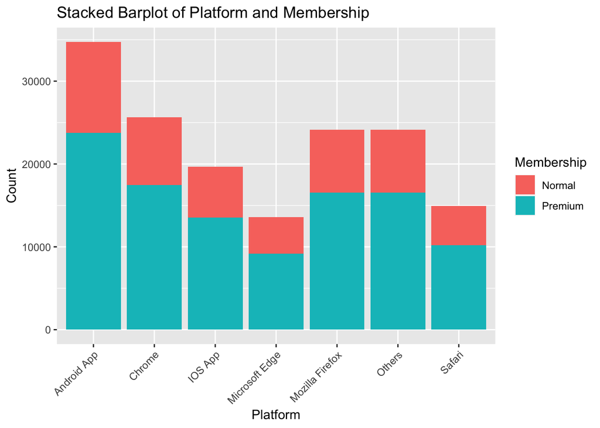

```r
 #Visual of frequency distribution

 ggplot(E_commerce_data_prepared1, aes(x = platform_used, fill = membership)) +
  geom_bar() +
  labs(title = "Stacked Barplot of Platform and Membership",
       x = "Platform",
       y = "Count", fill = "Membership") + theme(axis.text.x = element_text(angle = 45, hjust = 1))
```

Observing the contingency table comparing user membership status and platform usage reveals a significant 116% increase in total premium memberships compared to normal memberships overall, emphasizing a clear preference for premium memberships on the website.

Examining the row percentages of users within each platform uncovers a consistent trend – users, regardless of the platform, exhibit a preference for premium membership. The data shows a general 32% preference for normal and a 68% preference for premium memberships across all platforms.

Further exploration of relative proportions in each column underscores the similarity in preferences between membership types regarding platform usage. Users consistently favor Android, Chrome, Others, and Mozilla Firefox platforms, with comparable proportions seen in both premium and normal membership users.

A stacked barplot visually represents the counts and proportions of membership types across different platforms, providing a clear and intuitive overview of the aforementioned trends. In summary, the contingency table reveals a widespread and consistent preference for premium memberships across platforms, with users also favoring specific platforms for accessing the e-commerce website.

```r
 #Contingency table - gender and membership

 my.ctable2 <- table(E_commerce_data_prepared1$membership, E_commerce_data_prepared1$gender)

 #Relative frequencies

 addmargins(my.ctable2) #add up row/column totals
```

```
##
##           Female   Male    Sum
##   Normal   29636  19924  49560
##   Premium  64182  43070 107252
##   Sum      93818  62994 156812
```

```r
 proportions(my.ctable2) #proportions of all users in data
```

```
##
##              Female      Male
##   Normal  0.1889906 0.1270566
##   Premium 0.4092927 0.2746601
```

```r
 proportions(my.ctable2, 1) #row proportions
```

```
##
##              Female      Male
##   Normal  0.5979822 0.4020178
##   Premium 0.5984224 0.4015776
```

```r
 proportions(my.ctable2, 2) #column proportions
```

```
##
##              Female      Male
##   Normal  0.3158882 0.3162841
##   Premium 0.6841118 0.6837159
```

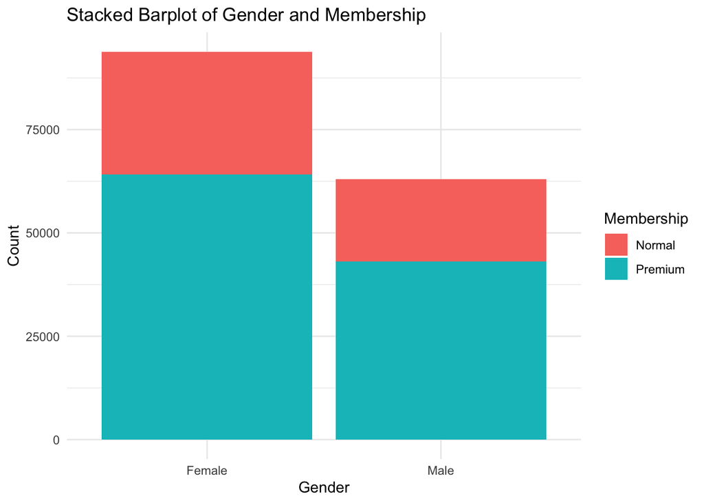

```r
 #Stacked barplot

 ggplot(E_commerce_data_prepared1, aes(x = gender, fill = membership)) +
  geom_bar() +
  labs(title = "Stacked Barplot of Gender and Membership",
       x = "Gender",
       y = "Count", fill = "Membership") +
  theme_minimal()
```

The relative frequency table indicates only a marginal difference in membership preferences between male and female users, with both genders showing a preference for premium membership at a rate of about 68%. Despite a higher percentage of female visitors to the site (60% vs. 40%), their membership preferences exhibit a similar pattern.

Notably, 41% of all users who make purchases on the website are female premium members, compared to 27% for males, suggesting that female premium members may contribute significantly to site sales. The stacked barplot visually affirms greater female counts in both membership types, while showing similar proportions between normal and premium memberships for both genders.

```r
 #Contingency table - country and membership

 my.ctable3 <- table(E_commerce_data_prepared1$membership, E_commerce_data_prepared1$country)

 #Relative frequencies

 addmargins(my.ctable3)
```

```
##
##               AE     AR     AT     AU     CA     CH     CN     CO     DE     DK
##   Normal      69    928   1392   1305   5049   2361   2975    426    638     69
##   Premium    130   1997   2937   2825  11063   5133   6229    944   1333    131
##   Sum        199   2925   4329   4130  16112   7494   9204   1370   1971    200
##
##               FI     FR     GB     IE     IN     IT     JP     KR     MX     NO
##   Normal     184     33   1401     65   2192   9921   2813    645    307   1031
##   Premium    409     61   3127    131   5096  21332   6230   1319    675   2330
##   Sum        593     94   4528    196   7288  31253   9043   1964    982   3361
##
##               PE     PL     PR     RU     SE     US     ZA    Sum
##   Normal     316   1873    518   2781   1313   8715    240  49560
##   Premium    656   4190   1058   5851   2786  18864    415 107252
##   Sum        972   6063   1576   8632   4099  27579    655 156812
```

```r
 proportions(my.ctable3)
```

```
##
##                     AE           AR           AT           AU           CA
##   Normal  0.0004400173 0.0059179144 0.0088768717 0.0083220672 0.0321977910
##   Premium 0.0008290182 0.0127349948 0.0187294340 0.0180152029 0.0705494477
##
##                     CH           CN           CO           DE           DK
##   Normal  0.0150562457 0.0189717624 0.0027166288 0.0040685662 0.0004400173
##   Premium 0.0327334643 0.0397227253 0.0060199475 0.0085006250 0.0008353953
##
##                     FI           FR           GB           IE           IN
##   Normal  0.0011733796 0.0002104431 0.0089342652 0.0004145091 0.0139785221
##   Premium 0.0026082188 0.0003890008 0.0199410759 0.0008353953 0.0324975129
##
##                     IT           JP           KR           MX           NO
##   Normal  0.0632668418 0.0179386782 0.0041132056 0.0019577583 0.0065747519
##   Premium 0.1360355075 0.0397291024 0.0084113461 0.0043045175 0.0148585567
##
##                     PE           PL           PR           RU           SE
##   Normal  0.0020151519 0.0119442390 0.0033033186 0.0177346121 0.0083730837
##   Premium 0.0041833533 0.0267198939 0.0067469326 0.0373121955 0.0177664975
##
##                     US           ZA
##   Normal  0.0555761039 0.0015304951
##   Premium 0.1202969161 0.0026464811
```

```r
 proportions(my.ctable3, 1) #row proportions
```

```
##
##                     AE           AR           AT           AU           CA
##   Normal  0.0013922518 0.0187247780 0.0280871671 0.0263317191 0.1018765133
##   Premium 0.0012120986 0.0186196994 0.0273841047 0.0263398352 0.1031495916
##
##                     CH           CN           CO           DE           DK
##   Normal  0.0476392252 0.0600282486 0.0085956416 0.0128732849 0.0013922518
##   Premium 0.0478592474 0.0580781710 0.0088017007 0.0124286727 0.0012214224
##
##                     FI           FR           GB           IE           IN
##   Normal  0.0037126715 0.0006658596 0.0282687651 0.0013115416 0.0442292171
##   Premium 0.0038134487 0.0005687540 0.0291556335 0.0012214224 0.0475142655
##
##                     IT           JP           KR           MX           NO
##   Normal  0.2001815981 0.0567594835 0.0130145278 0.0061945117 0.0208030670
##   Premium 0.1988960579 0.0580874949 0.0122981390 0.0062935889 0.0217245366
##
##                     PE           PL           PR           RU           SE
##   Normal  0.0063761098 0.0377925747 0.0104519774 0.0561138015 0.0264931396
##   Premium 0.0061164361 0.0390668705 0.0098646179 0.0545537612 0.0259762056
##
##                     US           ZA
##   Normal  0.1758474576 0.0048426150
##   Premium 0.1758848320 0.0038693917
```

```r
 proportions(my.ctable3, 2) #column proportions
```

```
##
##                  AE        AR        AT        AU        CA        CH        CN
##   Normal  0.3467337 0.3172650 0.3215523 0.3159806 0.3133689 0.3150520 0.3232290
##   Premium 0.6532663 0.6827350 0.6784477 0.6840194 0.6866311 0.6849480 0.6767710
##
##                  CO        DE        DK        FI        FR        GB        IE
##   Normal  0.3109489 0.3236936 0.3450000 0.3102867 0.3510638 0.3094081 0.3316327
##   Premium 0.6890511 0.6763064 0.6550000 0.6897133 0.6489362 0.6905919 0.6683673
##
##                  IN        IT        JP        KR        MX        NO        PE
##   Normal  0.3007684 0.3174415 0.3110693 0.3284114 0.3126273 0.3067539 0.3251029
##   Premium 0.6992316 0.6825585 0.6889307 0.6715886 0.6873727 0.6932461 0.6748971
##
##                  PL        PR        RU        SE        US        ZA
##   Normal  0.3089230 0.3286802 0.3221733 0.3203220 0.3160013 0.3664122
##   Premium 0.6910770 0.6713198 0.6778267 0.6796780 0.6839987 0.6335878
```

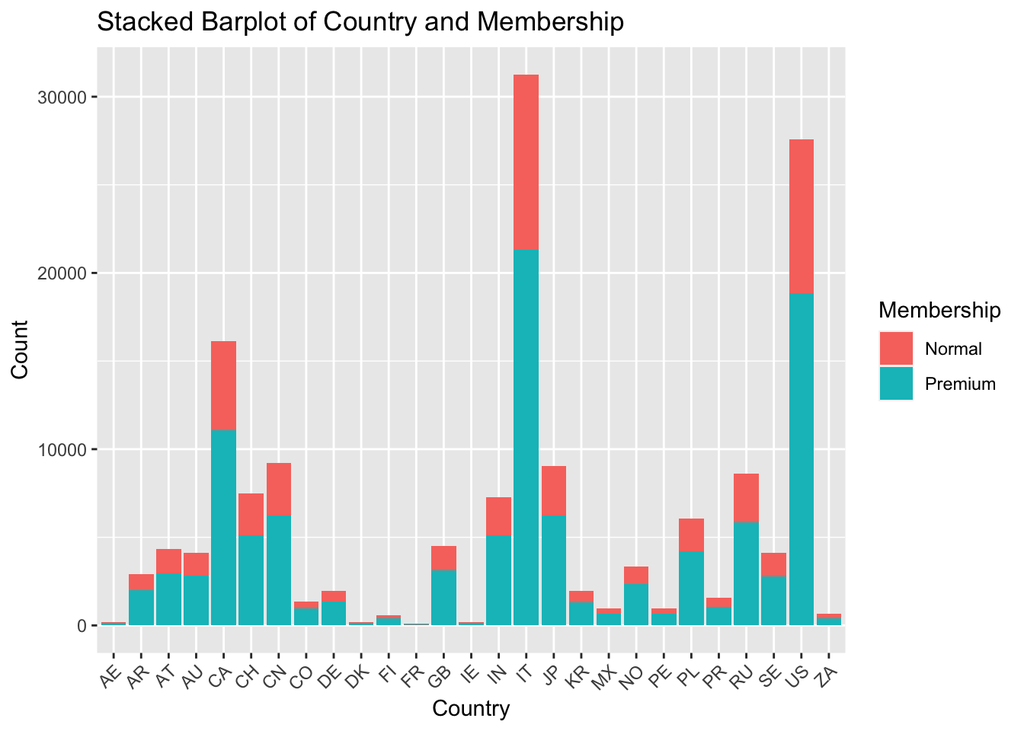

```r
 #Stacked barplot

 ggplot(E_commerce_data_prepared1, aes(x = country, fill = membership)) +
  geom_bar() +
  labs(title = "Stacked Barplot of Country and Membership",
       x = "Country",
       y = "Count", fill = "Membership") +
  theme(axis.text.x = element_text(angle = 45, hjust = 1))
```

From our visualization, it’s evident that Italy, the United States, and Canada boast the highest membership rates. Additionally, these countries harbor the largest number of Premium members, with Italy leading the pack. As such, these regions may prove the most promising for marketing strategies.

```r
 #Contingency table - language and membership

 my.ctable5 <- table(E_commerce_data_prepared1$membership, E_commerce_data_prepared1$language)

 #Relative frequencies

 addmargins(my.ctable5)
```

```
##
##           Arabic Chinese  Dutch English French German Italian Japanese
##   Normal     107    4086    138   32060   2024    628    1675      413
##   Premium    240    6086    394   74515   3843   1497    2221      762
##   Sum        347   10172    532  106575   5867   2125    3896     1175
##
##           Macedonian  Malay Malayalam Marathi Mongolian Nepali Norwegian
##   Normal          17     18        55       6        60     41        30
##   Premium         25     33       128      15       155     92        73
##   Sum             42     51       183      21       215    133       103
##
##           Persian Polish Portuguese Romanian Russian Serbian Slovak Slovene
##   Normal      237     69        102       21    3410       8     32      22
##   Premium     483    156        260       41    7617      17     57      59
##   Sum         720    225        362       62   11027      25     89      81
##
##           Spanish Swahili Swedish Tegulu   Thai   Urdu    Sum
##   Normal     3934      53      40     10    242     22  49560
##   Premium    7768      75      89     14    485     52 107252
##   Sum       11702     128     129     24    727     74 156812
```

```r
 proportions(my.ctable5)
```

```
##
##                 Arabic      Chinese        Dutch      English       French
##   Normal  6.823457e-04 2.605668e-02 8.800347e-04 2.044486e-01 1.290718e-02
##   Premium 1.530495e-03 3.881081e-02 2.512563e-03 4.751868e-01 2.450705e-02
##
##                 German      Italian     Japanese   Macedonian        Malay
##   Normal  4.004796e-03 1.068158e-02 2.633727e-03 1.084101e-04 1.147871e-04
##   Premium 9.546463e-03 1.416346e-02 4.859322e-03 1.594266e-04 2.104431e-04
##
##              Malayalam      Marathi    Mongolian       Nepali    Norwegian
##   Normal  3.507385e-04 3.826238e-05 3.826238e-04 2.614596e-04 1.913119e-04
##   Premium 8.162641e-04 9.565594e-05 9.884448e-04 5.866898e-04 4.655256e-04
##
##                Persian       Polish   Portuguese     Romanian      Russian
##   Normal  1.511364e-03 4.400173e-04 6.504604e-04 1.339183e-04 2.174578e-02
##   Premium 3.080121e-03 9.948218e-04 1.658036e-03 2.614596e-04 4.857409e-02
##
##                Serbian       Slovak      Slovene      Spanish      Swahili
##   Normal  5.101650e-05 2.040660e-04 1.402954e-04 2.508737e-02 3.379843e-04
##   Premium 1.084101e-04 3.634926e-04 3.762467e-04 4.953703e-02 4.782797e-04
##
##                Swedish       Tegulu         Thai         Urdu
##   Normal  2.550825e-04 6.377063e-05 1.543249e-03 1.402954e-04
##   Premium 5.675586e-04 8.927888e-05 3.092876e-03 3.316073e-04
```

```r
 proportions(my.ctable5, 1) #row proportions
```

```
##
##                 Arabic      Chinese        Dutch      English       French
##   Normal  0.0021589992 0.0824455206 0.0027845036 0.6468926554 0.0408393866
##   Premium 0.0022377205 0.0567448626 0.0036735912 0.6947655988 0.0358314996
##
##                 German      Italian     Japanese   Macedonian        Malay
##   Normal  0.0126715093 0.0337974173 0.0083333333 0.0003430186 0.0003631961
##   Premium 0.0139577817 0.0207082385 0.0071047626 0.0002330959 0.0003076866
##
##              Malayalam      Marathi    Mongolian       Nepali    Norwegian
##   Normal  0.0011097659 0.0001210654 0.0012106538 0.0008272801 0.0006053269
##   Premium 0.0011934509 0.0001398575 0.0014451945 0.0008577929 0.0006806400
##
##                Persian       Polish   Portuguese     Romanian      Russian
##   Normal  0.0047820823 0.0013922518 0.0020581114 0.0004237288 0.0688054883
##   Premium 0.0045034125 0.0014545183 0.0024241972 0.0003822773 0.0710196546
##
##                Serbian       Slovak      Slovene      Spanish      Swahili
##   Normal  0.0001614205 0.0006456820 0.0004439064 0.0793785311 0.0010694108
##   Premium 0.0001585052 0.0005314586 0.0005501063 0.0724275538 0.0006992877
##
##                Swedish       Tegulu         Thai         Urdu
##   Normal  0.0008071025 0.0002017756 0.0048829701 0.0004439064
##   Premium 0.0008298214 0.0001305337 0.0045220602 0.0004848394
```

```r
 proportions(my.ctable5, 2) #column proportions
```

```
##
##              Arabic   Chinese     Dutch   English    French    German   Italian
##   Normal  0.3083573 0.4016909 0.2593985 0.3008210 0.3449804 0.2955294 0.4299281
##   Premium 0.6916427 0.5983091 0.7406015 0.6991790 0.6550196 0.7044706 0.5700719
##
##            Japanese Macedonian     Malay Malayalam   Marathi Mongolian
##   Normal  0.3514894  0.4047619 0.3529412 0.3005464 0.2857143 0.2790698
##   Premium 0.6485106  0.5952381 0.6470588 0.6994536 0.7142857 0.7209302
##
##              Nepali Norwegian   Persian    Polish Portuguese  Romanian
##   Normal  0.3082707 0.2912621 0.3291667 0.3066667  0.2817680 0.3387097
##   Premium 0.6917293 0.7087379 0.6708333 0.6933333  0.7182320 0.6612903
##
##             Russian   Serbian    Slovak   Slovene   Spanish   Swahili   Swedish
##   Normal  0.3092410 0.3200000 0.3595506 0.2716049 0.3361818 0.4140625 0.3100775
##   Premium 0.6907590 0.6800000 0.6404494 0.7283951 0.6638182 0.5859375 0.6899225
##
##              Tegulu      Thai      Urdu
##   Normal  0.4166667 0.3328748 0.2972973
##   Premium 0.5833333 0.6671252 0.7027027
```

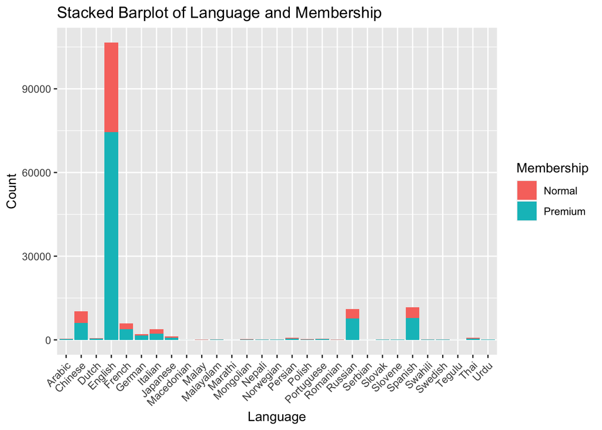

```r
 #Stacked barplot

 ggplot(E_commerce_data_prepared1, aes(x = language, fill =  membership)) +
  geom_bar() +
  labs(title = "Stacked Barplot of Language and Membership",
       x = "Language",
       y = "Count", fill = "Membership") + theme(axis.text.x = element_text(angle = 45, hjust = 1))
```

The visualization unmistakably indicates that the majority of paying site members are English speakers. Therefore, it may be advisable to suggest that marketing targets this demographic. Further analysis will be needed to see if there is a statistically significant association between language and membership.

```r
 #Contingency table - payment method and membership

 my.ctable4 <- table(E_commerce_data_prepared1$membership, E_commerce_data_prepared1$pay_method)

 #Relative frequencies

 addmargins(my.ctable4)
```

```
##
##             Cash Credit Card Debit Card Others    Sum
##   Normal   20888       15257       7750   5665  49560
##   Premium  45018       32831      17238  12165 107252
##   Sum      65906       48088      24988  17830 156812
```

```r
 proportions(my.ctable4)
```

```
##
##                 Cash Credit Card Debit Card     Others
##   Normal  0.13320409  0.09729485 0.04942224 0.03612606
##   Premium 0.28708262  0.20936535 0.10992781 0.07757697
```

```r
 proportions(my.ctable4, 1) #row proportions
```

```
##
##                Cash Credit Card Debit Card    Others
##   Normal  0.4214689   0.3078491  0.1563761 0.1143059
##   Premium 0.4197404   0.3061108  0.1607243 0.1134245
```

```r
 proportions(my.ctable4, 2) #column proportions
```

```
##
##                Cash Credit Card Debit Card    Others
##   Normal  0.3169362   0.3172725  0.3101489 0.3177229
##   Premium 0.6830638   0.6827275  0.6898511 0.6822771
```

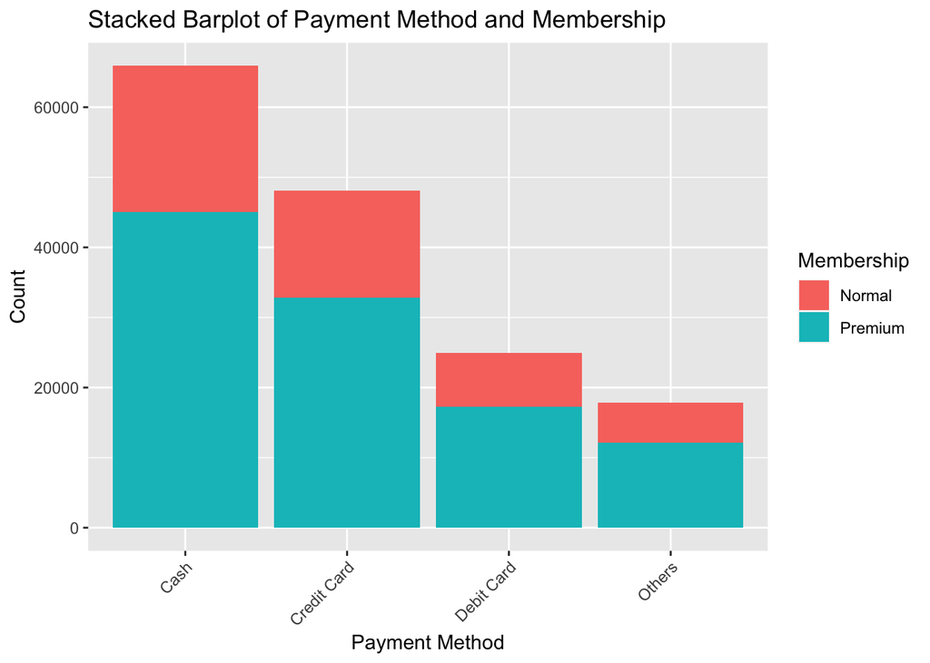

```r
 #Stacked barplot

 ggplot(E_commerce_data_prepared1, aes(x = pay_method, fill =  membership)) +
  geom_bar() +
  labs(title = "Stacked Barplot of Payment Method and Membership",
       x = "Payment Method",
       y = "Count", fill = "Membership") + theme(axis.text.x = element_text(angle = 45, hjust = 1))
```

Upon examining the global proportions within our contingency table, it becomes apparent that paying users exhibit a preference for utilizing cash, credit cards, and debit cards when making purchases on the website, irrespective of their membership status (normal or premium). This discernible trend is illustrated in the stacked barplot. Further validation from both row and column proportions reinforces the notion that the distribution of preferences for payment methods among members appears strikingly similar. Still, premium users constitute the majority in each payment method category, yet the proportional preferences remain consistent across both membership types.

With our data now prepared and processed, we’ve laid the groundwork for in-depth analysis. In the upcoming “Analyze” phase, we’ll delve into potential associations among variables, explore numerical data using descriptive statistics and graphs, investigate relationships with the sales variable, and conduct additional statistical tests. These steps will contribute to data-driven insights and actionable recommendations for stakeholders.

## Analyze: Unveiling Patterns

As we transition into the “Analyze” phase of our EDA journey, the groundwork laid in the “Ask, Prepare, and Process” phases paves the way towards discovering deeper insights. With an understanding of potential key relationships among our prepared dataset, we finally turn our attention towards discovering the intricacies within the data. This phase promises to uncover nuanced patterns and deliver data-driven revelations that will help guide strategic decisions. Join me as I embark on the next leg of our data exploration, ready to extract actionable insights to shape the future of the e-commerce marketing strategies.

We begin our analysis by exploring our numerical data using descriptive statistics to get an overview of the variables center and spread.

```r
 #Quantitative analysis

 #Univariate

 summary(E_commerce_data_prepared1$sales) #summary stats/standard deviations
```

```
##     Min.  1st Qu.   Median     Mean  3rd Qu.     Max.
##     0.00    15.15    75.75   452.98   600.16 11199.97
```

```r
 sd(E_commerce_data_prepared1$sales)
```

```
## [1] 812.8264
```

```r
 summary(E_commerce_data_prepared1$duration_min)
```

```
##    Min. 1st Qu.  Median    Mean 3rd Qu.    Max.
##   25.00   39.53   54.10   54.14   68.73   83.33
```

```r
 sd(E_commerce_data_prepared1$duration_min)
```

```
## [1] 16.84351
```

```r
 summary(E_commerce_data_prepared1$total_bytes)
```

```
##    Min. 1st Qu.  Median    Mean 3rd Qu.    Max.
##      28     463     639    1657    2883  932858
```

```r
 sd(E_commerce_data_prepared1$total_bytes)
```

```
## [1] 6644.346
```

```r
 summary(E_commerce_data_prepared2$age)
```

```
##    Min. 1st Qu.  Median    Mean 3rd Qu.    Max.
##   18.00   30.00   43.00   43.44   56.00   69.00
```

```r
 sd(E_commerce_data_prepared2$age)
```

```
## [1] 14.97965
```

Through our summary statistics and standard deviations, we are able to get an overview of the central tendency and variability of our numerical data. As shown, the mean and median for the age and duration of time spent on the website appear to be very similar, as the standard deviation values are both small, suggesting a relatively low amount of variability and spread.

The sales and total bytes variables, however, have a much larger interquartile range and a much higher standard deviation, which suggests that the data is much more dispersed. The mean and medians of these variables are also not similar. This is likely caused by the presence of outlying values, as seen by the very high maximum values, which likely is leading to the large skewness of the data. In this case, the median values values would give us a better overview of where the center of the data lies for the ‘sales’ and ‘total bytes’ variables.

To continue exploration of our data, we will look further into our summary statistics across different categorical groups.

```r
 #Descriptive statistics between categorical variables

 favstats(sales ~ gender, data = E_commerce_data_prepared1)
```

```
##   gender min    Q1 median     Q3      max     mean       sd     n missing
## 1 Female   0 15.15  75.75 600.16 11199.97 453.5969 813.3356 93818       0
## 2   Male   0 15.15  75.75 600.16 10499.97 452.0559 812.0729 62994       0
```

```r
 favstats(sales ~ membership, data = E_commerce_data_prepared1)
```

```
##   membership min    Q1 median     Q3      max     mean       sd      n missing
## 1     Normal   0 15.15  75.75 600.16  5443.96 457.2588 811.5358  49560       0
## 2    Premium   0 15.15  72.00 600.16 11199.97 450.9997 813.4182 107252       0
```

```r
 favstats(sales ~ age, data = E_commerce_data_prepared2)
```

```
##    age min       Q1  median      Q3      max     mean       sd    n missing
## 1   18   0 15.69000 71.6800 600.160  5250.00 421.4752 769.4133 1544       0
## 2   19   0 15.62100 71.6800 600.160  5250.00 413.8293 776.2991 1651       0
## 3   20   0 15.15000 71.6800 600.160  5250.00 407.9541 762.9949 1567       0
## 4   21   0 14.90000 69.4560 600.160  5443.96 410.7213 748.1713 1629       0
## 5   22   0 12.46800 71.6800 600.160 10499.97 424.1451 822.8182 1744       0
## 6   23   0 15.69000 81.3200 600.160  5250.00 458.0763 789.2805 1591       0
## 7   24   0 15.69000 75.8150 600.160  5250.00 466.8480 843.0966 1694       0
## 8   25   0 15.52000 75.7500 600.160  5250.00 420.1760 759.1342 1608       0
## 9   26   0 15.15000 71.6800 600.160  5250.00 416.0098 784.2760 1628       0
## 10  27   0 15.69000 71.6800 600.160  5250.00 425.3417 789.5523 1661       0
## 11  28   0 15.15000 74.6495 600.160  5250.00 423.6903 762.3991 1650       0
## 12  29   0 15.15000 71.6800 600.160  5250.00 414.7281 744.1356 1606       0
## 13  30   0 12.96000 60.6000 600.160  5250.00 419.3407 789.0719 1697       0
## 14  31   0 14.44800 68.6900 600.160  5250.00 427.1208 810.1791 1598       0
```

[output cut: 38 more lines]

```r
 favstats(sales ~ language, data = E_commerce_data_prepared1)
```

```
##      language min      Q1  median       Q3      max     mean        sd      n
## 1      Arabic   0 19.6160  71.680  600.160  5250.00 409.6922  765.4080    347
## 2     Chinese   0 15.1500  53.920  227.976 11199.97 292.0108  624.7543  10172
## 3       Dutch   0 15.0875  60.600  600.160  5250.00 400.5431  695.0515    532
## 4     English   0 15.1500  75.750  600.160  5399.91 468.8603  824.3105 106575
## 5      French   0 14.7600  69.576  600.160  5250.00 422.4298  792.6720   5867
## 6      German   0 15.1500  71.680  600.160  5250.00 445.9757  842.8476   2125
## 7     Italian   0 15.1500  75.750  600.160  5250.00 492.3925  876.1114   3896
## 8    Japanese   0 15.6900  81.320  600.160  5250.00 467.9576  823.2932   1175
## 9  Macedonian   0 16.9975  40.660  600.160  2400.68 410.9811  652.3621     42
## 10      Malay   0 11.7300 107.520  750.205  5250.00 594.2618 1117.0464     51
## 11  Malayalam   0 10.4600  75.750  600.160  5250.00 429.2799  855.6657    183
## 12    Marathi   0 15.6900 143.360  600.170  5250.00 783.8667 1556.2718     21
## 13  Mongolian   0 20.9200  81.320  600.170  5250.00 487.4201  780.1613    215
## 14     Nepali   0 15.6900  60.600  503.960  5250.00 434.8527  892.6786    133
```

[output cut: 45 more lines]

```r
 favstats(sales ~ platform_used, data = E_commerce_data_prepared1)
```

```
##     platform_used min    Q1 median     Q3      max     mean       sd     n
## 1     Android App   0 15.15 75.750 600.16  5250.00 456.3237 815.7211 34733
## 2          Chrome   0 15.15 75.750 600.16  5443.96 451.7499 808.1752 25628
## 3         IOS App   0 15.15 75.750 600.16 11199.97 453.4538 810.9228 19684
## 4  Microsoft Edge   0 15.15 71.680 600.16 10499.97 450.6757 815.1730 13576
## 5 Mozilla Firefox   0 15.15 71.976 600.16 10499.97 448.9357 807.1286 24117
## 6          Others   0 15.15 71.990 600.16  5443.96 455.6240 825.3044 24120
## 7          Safari   0 14.49 75.750 600.16  5250.00 451.0256 803.3457 14954
##   missing
## 1       0
## 2       0
## 3       0
## 4       0
## 5       0
## 6       0
## 7       0
```

```r
 favstats(sales ~ country, data = E_commerce_data_prepared1)
```

```
##    country min      Q1 median      Q3      max     mean       sd     n missing
## 1       AE   0 10.4600 40.660 245.668  5250.00 375.9004 736.7285   199       0
## 2       AR   0 13.2480 71.680 600.160  5250.00 441.7022 790.5878  2925       0
## 3       AT   0 14.8500 71.680 600.160  5250.00 460.6075 827.7368  4329       0
## 4       AU   0 15.1500 71.680 600.160  5250.00 448.8785 788.7689  4130       0
## 5       CA   0 14.0400 75.750 600.160  5250.00 453.6291 812.8455 16112       0
## 6       CH   0 14.7150 71.680 600.160  5250.00 440.0783 798.6440  7494       0
## 7       CN   0 15.1500 75.750 600.160  5443.96 452.5215 813.2672  9204       0
## 8       CO   0 15.1500 71.680 600.160  5250.00 443.1436 812.9282  1370       0
## 9       DE   0 12.6900 71.680 600.160  5250.00 458.9382 839.5968  1971       0
## 10      DK   0 20.9200 87.284 600.170  5250.00 505.7064 866.7948   200       0
## 11      FI   0 15.6900 81.320 600.160 10499.97 474.0539 842.6644   593       0
## 12      FR   0 21.5550 71.680 600.160  3000.85 455.3120 728.5298    94       0
## 13      GB   0 11.7300 71.680 600.160 10499.97 444.1010 813.5140  4528       0
## 14      IE   0 15.5550 60.735 600.160  5250.00 501.7955 938.0212   196       0
## 15      IN   0 15.1500 75.750 600.160  5250.00 453.8055 809.2102  7288       0
## 16      IT   0 14.9400 73.980 600.160  5443.96 450.3794 818.8943 31253       0
## 17      JP   0 13.0890 75.750 600.160 11199.97 461.7716 834.3906  9043       0
## 18      KR   0 15.3255 75.750 600.160  5250.00 449.7949 765.7206  1964       0
## 19      MX   0 15.1500 81.320 600.160  5250.00 469.4509 853.5575   982       0
## 20      NO   0 15.1500 71.680 600.160  5250.00 446.5414 794.2658  3361       0
## 21      PE   0 15.6900 75.750 600.160  5250.00 437.2801 776.4663   972       0
## 22      PL   0 15.6900 81.320 600.160  5250.00 477.1318 853.4230  6063       0
## 23      PR   0 15.1500 75.750 600.160  5250.00 450.5537 781.9899  1576       0
## 24      RU   0 15.1500 71.680 600.160  5250.00 444.6587 788.9662  8632       0
## 25      SE   0 15.1650 81.320 600.160  5250.00 454.5408 799.3874  4099       0
## 26      US   0 15.1500 75.750 600.160  5399.91 456.5572 811.0108 27579       0
## 27      ZA   0 15.6900 71.680 600.160  5250.00 419.9612 808.3100   655       0
```

Due to the amount of variability within the ‘sales’ variable as indicated from its outlying values, large differences in mean and median, and large interquartile range and standard deviation; we should expect to see some variability within the descriptive statistics of different groups, and their resulting factors.

As expected, the mean/median tends to vary between the different levels of the groups. Nonetheless, between the different genders the median value remains the same at 75 dollars. Further statistical tests will be needed to see if any statistical significance is apparent between any of the groups.

```r
 favstats(duration_min ~ gender, data = E_commerce_data_prepared1)
```

```
##   gender min       Q1   median       Q3      max     mean       sd     n
## 1 Female  25 39.55000 54.10000 68.68333 83.33333 54.13723 16.83191 93818
## 2   Male  25 39.50417 54.13333 68.78333 83.33333 54.15119 16.86089 62994
##   missing
## 1       0
## 2       0
```

```r
 favstats(duration_min ~ membership, data = E_commerce_data_prepared1)
```

```
##   membership min       Q1   median       Q3      max     mean       sd      n
## 1     Normal  25 39.53333 54.10833 68.85000 83.33333 54.16670 16.86957  49560
## 2    Premium  25 39.53333 54.10000 68.66667 83.33333 54.13181 16.83152 107252
##   missing
## 1       0
## 2       0
```

```r
 favstats(duration_min ~ age, data = E_commerce_data_prepared2)
```

```
##    age      min       Q1   median       Q3      max     mean       sd    n
## 1   18 25.01667 39.31667 54.80000 68.59167 83.30000 54.42146 16.92515 1544
## 2   19 25.01667 39.57500 54.15000 68.79167 83.33333 54.17471 16.94945 1651
## 3   20 25.00000 39.76667 54.03333 68.35000 83.26667 54.08768 16.59355 1567
## 4   21 25.03333 39.83333 53.96667 68.58333 83.31667 54.17472 16.63655 1629
## 5   22 25.00000 38.83333 54.42500 68.86250 83.31667 54.19339 17.18522 1744
## 6   23 25.08333 39.42500 54.11667 69.55833 83.31667 54.29453 17.05676 1591
## 7   24 25.05000 39.63333 54.74167 69.05000 83.33333 54.39691 16.97573 1694
## 8   25 25.00000 39.87917 54.46667 68.85000 83.33333 54.53961 16.70743 1608
## 9   26 25.03333 39.59583 54.24167 68.90000 83.26667 54.48839 16.84408 1628
## 10  27 25.01667 39.88333 54.41667 68.40000 83.33333 54.33078 16.74367 1661
## 11  28 25.05000 39.18750 53.21667 68.93750 83.30000 53.77189 17.04091 1650
## 12  29 25.01667 40.20000 54.82500 68.81667 83.33333 54.42193 16.85844 1606
## 13  30 25.11667 38.20000 53.61667 68.01667 83.31667 53.49223 17.22329 1697
## 14  31 25.05000 39.39167 53.52500 68.68750 83.30000 53.87071 17.08018 1598
```

[output cut: 91 more lines]

```r
 favstats(duration_min ~ language, data = E_commerce_data_prepared1)
```

```
##      language      min       Q1   median       Q3      max     mean       sd
## 1      Arabic 25.03333 37.91667 55.35000 69.96667 83.08333 54.15067 17.41774
## 2     Chinese 25.00000 39.53333 54.25000 68.97083 83.33333 54.31338 16.88549
## 3       Dutch 25.03333 37.49583 54.75000 67.96250 83.30000 53.65996 17.15497
## 4     English 25.00000 39.48333 54.06667 68.63333 83.33333 54.08132 16.84117
## 5      French 25.00000 39.90000 54.73333 69.06667 83.33333 54.48746 16.82749
## 6      German 25.05000 38.30000 51.96667 67.56667 83.33333 52.92416 16.77314
## 7     Italian 25.00000 39.56667 54.00000 68.91667 83.33333 54.19074 16.85041
## 8    Japanese 25.05000 39.68333 54.71667 69.09167 83.33333 54.50106 16.83991
## 9  Macedonian 26.50000 39.74583 53.43333 68.50833 81.70000 53.47222 16.70229
## 10      Malay 25.91667 35.65833 50.43333 66.02500 83.23333 51.33105 17.78172
## 11  Malayalam 25.86667 41.89167 56.06667 72.55000 83.03333 56.33087 17.08491
## 12    Marathi 25.20000 38.88333 56.55000 65.33333 82.61667 52.65714 16.85687
## 13  Mongolian 25.08333 42.52500 57.91667 70.95833 83.03333 56.52597 16.37671
## 14     Nepali 25.26667 42.10000 56.15000 70.85000 83.10000 55.93697 17.17292
```

[output cut: 45 more lines]

```r
 favstats(duration_min ~ platform_used, data = E_commerce_data_prepared1)
```

```
##     platform_used min       Q1   median       Q3      max     mean       sd
## 1     Android App  25 39.63333 54.06667 68.91667 83.33333 54.22109 16.85001
## 2          Chrome  25 39.78333 54.41667 68.78333 83.33333 54.27176 16.78646
## 3         IOS App  25 39.51667 54.18333 68.80000 83.33333 54.16522 16.86518
## 4  Microsoft Edge  25 39.69583 54.55000 68.91667 83.33333 54.29378 16.87780
## 5 Mozilla Firefox  25 39.36667 53.95000 68.55000 83.33333 54.00970 16.81980
## 6          Others  25 39.33333 53.78333 68.50000 83.33333 53.99081 16.83313
## 7          Safari  25 39.35000 53.97500 68.56667 83.33333 54.03354 16.92024
##       n missing
## 1 34733       0
## 2 25628       0
## 3 19684       0
## 4 13576       0
## 5 24117       0
## 6 24120       0
## 7 14954       0
```

```r
 favstats(duration_min ~ country, data = E_commerce_data_prepared1)
```

```
##    country      min       Q1   median       Q3      max     mean       sd     n
## 1       AE 25.13333 43.81667 55.06667 69.70833 83.23333 55.26642 16.27788   199
## 2       AR 25.00000 39.65000 54.48333 68.61667 83.33333 54.24441 16.75694  2925
## 3       AT 25.00000 39.38333 53.96667 68.63333 83.31667 54.02786 16.78543  4329
## 4       AU 25.00000 39.22083 54.11667 69.11250 83.33333 54.19573 17.06876  4130
## 5       CA 25.00000 39.45000 54.36667 68.85000 83.33333 54.22167 16.93749 16112
## 6       CH 25.00000 39.53333 53.49167 68.09583 83.33333 53.85695 16.68800  7494
## 7       CN 25.00000 39.69583 54.15000 68.90000 83.33333 54.23319 16.80489  9204
## 8       CO 25.01667 38.95417 54.59167 69.27500 83.31667 54.18606 17.22028  1370
## 9       DE 25.00000 40.28333 54.21667 68.29167 83.31667 54.27516 16.49075  1971
## 10      DK 25.01667 40.49583 53.45833 67.94583 83.28333 54.16675 16.09297   200
## 11      FI 25.15000 39.26667 54.33333 69.60000 83.11667 54.51737 17.06728   593
## 12      FR 25.71667 40.12917 54.82500 67.67500 83.30000 54.61152 16.44479    94
## 13      GB 25.01667 39.34583 54.27500 69.45000 83.33333 54.38800 16.92465  4528
## 14      IE 25.01667 38.59583 55.02500 66.13750 82.58333 53.48988 16.06688   196
```

[output cut: 41 more lines]

Looking at our ‘duration_min’ variable gives us some useful insights. The mean and median values tend to be the same across different groups, and the variability also remains fairly constant. From the first and third quartiles, it appears that about half of the time spend on the website is expected to be between 40 and 69 minutes. This is least consistent across different languages and countries, yet the standard deviation and ensuing variation of the time spend on the website remains very consistent, despite the large difference in sample size among the various countries and languages.

```r
 favstats(age ~ gender, data = E_commerce_data_prepared2)
```

```
##   gender min Q1 median Q3 max     mean       sd     n missing
## 1 Female  18 30     43 56  69 43.46358 14.96259 50638       0
## 2   Male  18 30     43 56  69 43.40716 15.00517 34004       0
```

```r
 favstats(age ~ membership, data = E_commerce_data_prepared2)
```

```
##   membership min Q1 median Q3 max     mean       sd     n missing
## 1     Normal  18 31     43 56  69 43.46364 14.94757 29838       0
## 2    Premium  18 30     43 56  69 43.42855 14.99720 54804       0
```

```r
 favstats(age ~ language, data = E_commerce_data_prepared2)
```

```
##      language min    Q1 median    Q3 max     mean       sd     n missing
## 1      Arabic  18 30.00   45.0 55.00  69 43.51075 14.68783   186       0
## 2     Chinese  18 31.00   43.0 56.00  69 43.47257 14.96645 10172       0
## 3       Dutch  18 31.75   45.0 57.25  69 44.34028 15.29075   288       0
## 4     English  18 30.00   43.0 56.00  69 43.42900 14.97170 49939       0
## 5      French  18 30.00   44.0 57.00  69 43.56777 14.95380  3910       0
## 6      German  18 31.00   43.0 57.00  69 43.65291 14.83090   945       0
## 7     Italian  18 30.00   43.0 57.00  69 43.50371 15.07185  3643       0
## 8    Japanese  18 30.00   42.0 55.00  69 42.70284 15.02412   599       0
## 9  Macedonian  18 28.25   42.0 59.50  69 42.87500 17.30623    24       0
## 10      Malay  20 33.25   48.0 55.00  69 45.26667 14.67800    30       0
## 11  Malayalam  18 31.50   43.0 59.50  69 43.71579 15.89370    95       0
## 12    Marathi  19 36.50   49.0 54.50  59 44.00000 12.88410    11       0
## 13  Mongolian  18 28.00   43.0 54.75  69 42.64035 15.39402   114       0
## 14     Nepali  20 31.50   45.0 56.50  69 45.04225 14.41967    71       0
## 15  Norwegian  18 31.00   45.0 59.00  69 44.63793 16.15680    58       0
## 16    Persian  18 30.00   45.0 57.00  69 43.52250 15.18374   400       0
## 17     Polish  18 30.00   42.0 52.50  69 41.82114 14.99346   123       0
## 18 Portuguese  18 31.00   47.0 58.00  69 44.68342 14.92897   199       0
## 19   Romanian  18 28.50   39.5 54.25  69 42.16667 15.47256    36       0
## 20    Russian  18 30.00   43.0 56.00  69 43.18876 14.96847  6013       0
## 21    Serbian  18 31.00   51.5 55.75  69 46.21429 17.53317    14       0
## 22     Slovak  19 30.75   39.5 52.25  68 42.00000 14.46787    48       0
## 23    Slovene  18 29.75   40.5 52.25  68 41.77273 14.47349    44       0
## 24    Spanish  18 30.00   43.0 57.00  69 43.54478 15.04439  7124       0
## 25    Swahili  18 32.00   44.0 53.25  69 43.04167 14.46456    72       0
## 26    Swedish  18 32.50   41.0 56.00  69 43.19718 14.14276    71       0
## 27     Tegulu  23 48.00   56.0 62.00  69 53.00000 13.45982    13       0
## 28       Thai  18 32.00   44.0 56.00  69 43.94737 14.56747   361       0
## 29       Urdu  18 28.50   42.0 54.00  68 41.82051 15.72774    39       0
```

```r
 favstats(age ~ platform_used, data = E_commerce_data_prepared2)
```

```
##     platform_used min Q1 median Q3 max     mean       sd     n missing
## 1     Android App  18 30     43 56  69 43.32923 14.97539 18768       0
## 2          Chrome  18 30     43 56  69 43.28289 14.89978 13818       0
## 3         IOS App  18 31     44 57  69 43.66529 14.97515 10627       0
## 4  Microsoft Edge  18 31     44 57  69 43.77529 15.05575  7325       0
## 5 Mozilla Firefox  18 30     43 56  69 43.41667 14.97889 13015       0
## 6          Others  18 30     43 57  69 43.43792 15.05788 13007       0
## 7          Safari  18 31     43 56  69 43.41623 14.93493  8082       0
```

```r
 favstats(age ~ country, data = E_commerce_data_prepared2)
```

```
##    country min    Q1 median    Q3 max     mean       sd     n missing
## 1       AE  18 27.00   40.0 61.00  69 42.74074 16.63482   108       0
## 2       AR  18 31.00   43.0 56.00  69 43.55218 14.83028  1581       0
## 3       AT  18 30.00   43.0 56.00  69 43.14823 15.05249  2341       0
## 4       AU  18 31.00   43.0 57.00  69 43.57618 14.70974  2225       0
## 5       CA  18 30.00   43.0 56.00  69 43.23783 15.00999  8687       0
## 6       CH  18 30.00   43.0 57.00  69 43.30663 15.26357  4057       0
## 7       CN  18 31.00   44.0 56.00  69 43.64607 14.89325  4984       0
## 8       CO  18 30.00   44.0 56.00  69 43.37602 14.86594   734       0
## 9       DE  18 30.00   44.0 57.00  69 43.37312 15.27973  1064       0
## 10      DK  18 30.00   41.0 54.00  69 42.38532 14.34296   109       0
## 11      FI  18 33.00   44.0 57.75  69 44.58385 14.50752   322       0
## 12      FR  18 29.00   45.0 56.00  69 44.15094 16.50221    53       0
## 13      GB  18 30.00   43.0 56.00  69 42.99467 15.03969  2441       0
## 14      IE  18 30.75   42.5 55.25  69 43.25000 14.72814   108       0
## 15      IN  18 30.00   43.0 56.00  69 43.39635 15.08314  3941       0
## 16      IT  18 31.00   43.0 56.00  69 43.45318 14.91106 16872       0
## 17      JP  18 30.00   43.0 56.00  69 43.27012 14.98049  4883       0
## 18      KR  18 31.00   45.0 57.00  69 43.96887 14.89288  1060       0
## 19      MX  18 29.00   41.0 56.00  69 42.29032 14.97264   527       0
## 20      NO  18 30.00   43.0 57.00  69 43.24147 15.06086  1818       0
## 21      PE  18 33.00   45.0 56.75  69 44.26062 14.71573   518       0
## 22      PL  18 30.00   44.0 57.00  69 43.61790 15.09383  3274       0
## 23      PR  18 31.00   41.5 55.00  69 42.43647 14.59573   850       0
## 24      RU  18 30.00   43.0 57.00  69 43.53146 14.95745  4657       0
## 25      SE  18 31.00   44.0 57.00  69 43.98778 15.09782  2210       0
## 26      US  18 31.00   43.0 57.00  69 43.53401 14.98040 14597       0
## 27      ZA  18 32.00   45.0 57.00  69 44.37842 14.73005   621       0
```

Age tends to be consistent across the different groups, with a median and mean value that hovers around 40 to 45 years of age. Between genders, the first and third quartiles are the same, 30 to 56 years of age, which represents where 50% of the websites users age ranges are expected to land when accessing the site.

We can also visual and observe the data within the numerical variables using a histogram.

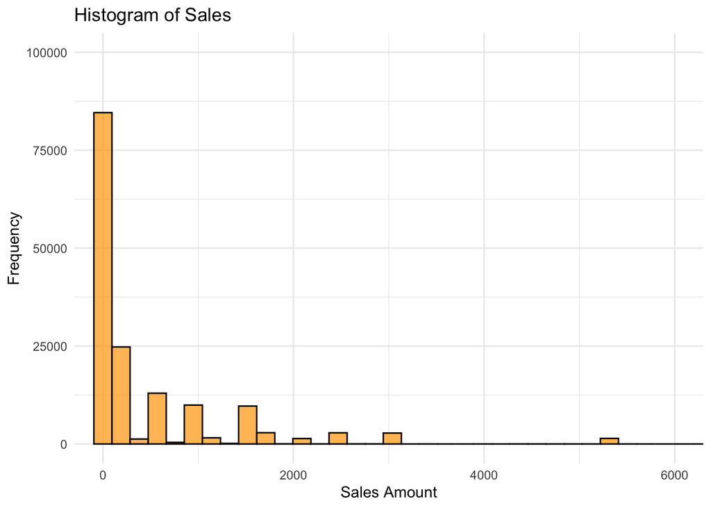

```r
 #Univariate numerical data visualizations

 ggplot(E_commerce_data_prepared1, aes(x = sales)) +
  geom_histogram(bins = 60, fill = "orange", color = "black", alpha = 0.7) +
  labs(title = "Histogram of Sales", x = "Sales Amount", y = "Frequency") +
  theme_minimal() +
  coord_cartesian(xlim = c(0,6000), ylim = c(0,100000))
```

From the histogram, it appears that the sales variable takes on a skewness to the right, as the majority of the website’s sales fall on the lower end of values, with a few that tail off to higher values.

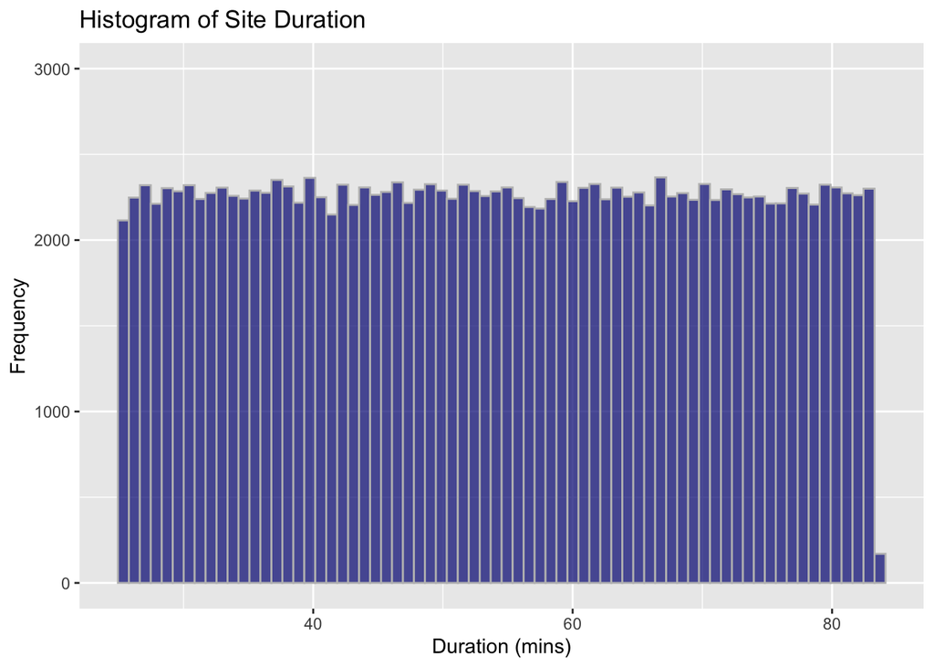

```r
 ggplot(E_commerce_data_prepared1, aes(x = duration_min)) +
   geom_histogram(bins = 70, fill = "navyblue", color = "grey", alpha = 0.7) +  labs(title = "Histogram of Site Duration", x = "Duration (mins)", y = "Frequency") +
   scale_y_continuous(limits = c(0, 3000), breaks = seq(0, 3000, 1000))
```

The time spent on the website takes on a uniform distribution, as users tend to spend anywhere between 25 and 83 minutes on the website.

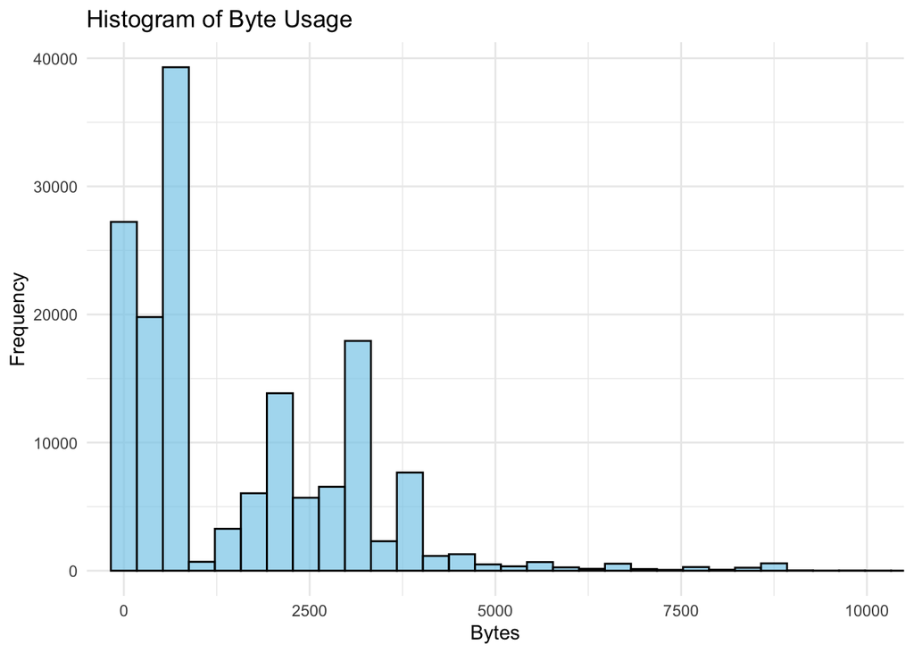

```r
 ggplot(E_commerce_data_prepared1, aes(x = total_bytes)) +
  geom_histogram(binwidth = 350, fill = "skyblue", color = "black", alpha = 0.7) +
  labs(title = "Histogram of Byte Usage", x = "Bytes", y = "Frequency") +
  theme_minimal() +
  coord_cartesian(xlim = c(0, 10000))
```

Like sales, the total bytes used by users is right skewed in its distribution. This may indicate that larger transactions that lead to a higher sales amount take up a higher byte usage.

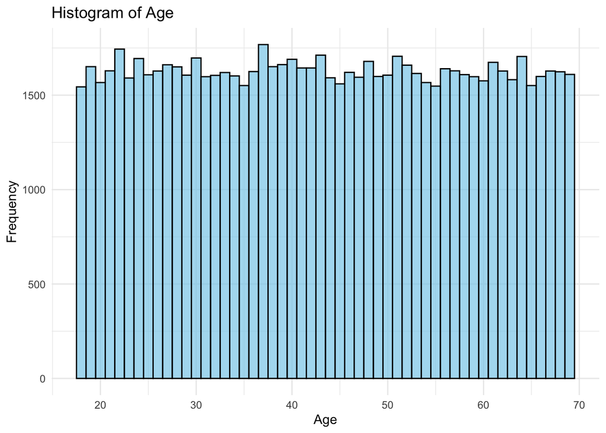

```r
 ggplot(E_commerce_data_prepared2, aes(x = age)) +
  geom_histogram(binwidth = 1, fill = "skyblue", color = "black", alpha = 0.7) +
  labs(title = "Histogram of Age", x = "Age", y = "Frequency") +
  theme_minimal() #uniform distribution
```

The visual display of the ages of users that access and are able to spend money on the website takes on a uniform distribution. This indicates that the ages of those that view the website each have a fairly equal likelihood of being between 18 and 69 years of age. Further analysis will be needed to see if any age group spends money on the site at a rate that is significantly higher than the other age groups, statistically speaking.

For the next phase in our analysis, we will be looking to see if any linear associations exist between our numerical data using correlation analysis.

```r
 #Statistical correlation analysis of bivariate numerical data

 cor(E_commerce_data_prepared1$sales, E_commerce_data_prepared1$total_bytes)
```

```
## [1] -0.000726865
```

```r
 cor(E_commerce_data_prepared2$sales, E_commerce_data_prepared2$age)
```

```
## [1] 0.002640661
```

```r
 cor(E_commerce_data_prepared1$sales, E_commerce_data_prepared1$duration_min)
```

```
## [1] -0.001415638
```

```r
 cor(E_commerce_data_prepared2$duration_min, E_commerce_data_prepared2$age)
```

```
## [1] 0.0009069796
```

```r
 cor(E_commerce_data_prepared1$duration_min, E_commerce_data_prepared1$total_bytes)
```

```
## [1] 0.004814116
```

```r
 cor(E_commerce_data_prepared2$age, E_commerce_data_prepared2$total_bytes)
```

```
## [1] 0.0008528759
```

By observing our correlation coefficients we see that all of our values hover around 0, which indicates that no linear correlation exists between the variables. So, we can not accurately predict or create a linear model that represents their relationships.

We will now run some statistical tests to observe if the sales on the website differs between the various categorical variables in any significant way.

```r
  #Median, total sales of each membership with percentage

  total_sales_median_memberships <- E_commerce_data_prepared1 %>%
  group_by(membership) %>%
  summarize(total_sales = sum(sales), median_sales = median(sales)) %>%
  mutate(percentage = round(total_sales / sum(total_sales) * 100, 2)) %>%
  arrange(desc(total_sales))

  total_sales_median_memberships
```

```
## # A tibble: 2 × 4
##   membership total_sales median_sales percentage
##   <chr>            <dbl>        <dbl>      <dbl>
## 1 Premium      48370621.         72         68.1
## 2 Normal       22661744.         75.8       31.9
```

```r
  #Median, total sales of genders

  total_sales_median_genders <- E_commerce_data_prepared1 %>%
  group_by(gender) %>%
  summarize(total_sales = sum(sales), median_sales = median(sales)) %>%
  mutate(percentage = round(total_sales / sum(total_sales) * 100, 2)) %>%
  arrange(desc(total_sales))

  total_sales_median_genders
```

```
## # A tibble: 2 × 4
##   gender total_sales median_sales percentage
##   <chr>        <dbl>        <dbl>      <dbl>
## 1 Female   42555558.         75.8       59.9
## 2 Male     28476808.         75.8       40.1
```

```r
  #Median, total sales of different ages

  total_sales_median_ages <- E_commerce_data_prepared2 %>%
  group_by(age) %>%
  summarize(total_sales = sum(sales), median_sales = median(sales)) %>%
  mutate(percentage = round(total_sales / sum(total_sales) * 100, 2)) %>%
  arrange(desc(total_sales))

  total_sales_median_ages
```

```
## # A tibble: 52 × 4
##      age total_sales median_sales percentage
##    <int>       <dbl>        <dbl>      <dbl>
##  1    24     790841.         75.8       2.21
##  2    61     745965.         75.8       2.08
##  3    58     744468.         80.3       2.08
##  4    22     739709.         71.7       2.07
##  5    37     736374.         71.7       2.06
##  6    51     732981.         71.7       2.05
##  7    33     729540.         75.3       2.04
##  8    23     728799.         81.3       2.04
##  9    43     719916.         71.7       2.01
## 10    64     718446.         75.8       2.01
## # ℹ 42 more rows
```

```r
  #Median, total sales of languages

  total_sales_median_language <- E_commerce_data_prepared1 %>%
  group_by(language) %>%
  summarize(total_sales = sum(sales), median_sales = median(sales)) %>%
  mutate(percentage = round(total_sales / sum(total_sales) * 100, 2)) %>%
  arrange(desc(total_sales))

  total_sales_median_language
```

```
## # A tibble: 29 × 4
##    language total_sales median_sales percentage
##    <chr>          <dbl>        <dbl>      <dbl>
##  1 English    49968792.         75.8      70.4
##  2 Spanish     5429948.         75.9       7.64
##  3 Russian     4856126.         75.8       6.84
##  4 Chinese     2970334.         53.9       4.18
##  5 French      2478395.         69.6       3.49
##  6 Italian     1918361.         75.8       2.7
##  7 German       947698.         71.7       1.33
##  8 Japanese     549850.         81.3       0.77
##  9 Thai         329814.         75.8       0.46
## 10 Persian      301283.         75.8       0.42
## # ℹ 19 more rows
```

```r
  #Median, total sales of each country

  total_sales_median_country <- E_commerce_data_prepared1 %>%
  group_by(country) %>%
  summarize(total_sales = sum(sales), median_sales = median(sales)) %>%
  mutate(percentage = round(total_sales / sum(total_sales) * 100, 2)) %>%
  arrange(desc(total_sales))

  total_sales_median_country
```

```
## # A tibble: 27 × 4
##    country total_sales median_sales percentage
##    <chr>         <dbl>        <dbl>      <dbl>
##  1 IT        14075707.         74.0      19.8
##  2 US        12591391.         75.8      17.7
##  3 CA         7308873.         75.8      10.3
##  4 JP         4175801.         75.8       5.88
##  5 CN         4165008.         75.8       5.86
##  6 RU         3838294.         71.7       5.4
##  7 IN         3307335.         75.8       4.66
##  8 CH         3297947.         71.7       4.64
##  9 PL         2892850.         81.3       4.07
## 10 GB         2010889.         71.7       2.83
## # ℹ 17 more rows
```

```r
  #Median, total sales of payment methods

  total_sales_median_payment <- E_commerce_data_prepared1 %>%
  group_by(pay_method) %>%
  summarize(total_sales = sum(sales), median_sales = median(sales)) %>%
  mutate(percentage = round(total_sales / sum(total_sales) * 100, 2)) %>%
  arrange(desc(total_sales))

  total_sales_median_payment
```

```
## # A tibble: 4 × 4
##   pay_method  total_sales median_sales percentage
##   <chr>             <dbl>        <dbl>      <dbl>
## 1 Cash          29734083.         75.8       41.9
## 2 Credit Card   22061788.         75.8       31.1
## 3 Debit Card    11205043.         71.7       15.8
## 4 Others         8031452.         75.8       11.3
```

```r
  #Median, total sales of platforms

  total_sales_median_platform <- E_commerce_data_prepared1 %>%
  group_by(platform_used) %>%
  summarize(total_sales = sum(sales), median_sales = median(sales)) %>%
  mutate(percentage = round(total_sales / sum(total_sales) * 100, 2)) %>%
  arrange(desc(total_sales))

  total_sales_median_platform
```

```
## # A tibble: 7 × 4
##   platform_used   total_sales median_sales percentage
##   <chr>                 <dbl>        <dbl>      <dbl>
## 1 Android App       15849490.         75.8      22.3
## 2 Chrome            11577447.         75.8      16.3
## 3 Others            10989652.         72.0      15.5
## 4 Mozilla Firefox   10826982.         72.0      15.2
## 5 IOS App            8925785.         75.8      12.6
## 6 Safari             6744637.         75.8       9.5
## 7 Microsoft Edge     6118373.         71.7       8.61
```

```r
  #Sales across multiple categories

  #Total sales by payment method, membership

 total_sales_by_membership_payment <- E_commerce_data_prepared1 %>%
   group_by(membership, pay_method) %>%
   summarize(total_sales = sum(sales)) %>%
   group_by(membership) %>%
   mutate(percentage = round(total_sales / sum(total_sales) * 100, 2)) %>%
   arrange(membership, desc(total_sales))

 total_sales_by_membership_payment
```

```
## # A tibble: 8 × 4
## # Groups:   membership [2]
##   membership pay_method  total_sales percentage
##   <chr>      <chr>             <dbl>      <dbl>
## 1 Normal     Cash           9389232.       41.4
## 2 Normal     Credit Card    7087638.       31.3
## 3 Normal     Debit Card     3572184.       15.8
## 4 Normal     Others         2612690.       11.5
## 5 Premium    Cash          20344851.       42.1
## 6 Premium    Credit Card   14974150.       31.0
## 7 Premium    Debit Card     7632859.       15.8
## 8 Premium    Others         5418761.       11.2
```

```r
 #Total sales by gender, membership

 total_sales_by_gender_membership <- E_commerce_data_prepared1 %>%
  filter(gender %in% c("Male", "Female")) %>%
  group_by(gender, membership) %>%
  summarize(total_sales = sum(sales, na.rm = TRUE)) %>%
  mutate(percentage = round((total_sales / sum(total_sales)) * 100, 2))

 total_sales_by_gender_membership
```

```
## # A tibble: 4 × 4
## # Groups:   gender [2]
##   gender membership total_sales percentage
##   <chr>  <chr>            <dbl>      <dbl>
## 1 Female Normal       13478392.       31.7
## 2 Female Premium      29077166.       68.3
## 3 Male   Normal        9183353.       32.2
## 4 Male   Premium      19293455.       67.8
```

```r
  #Total sales by language, membership

 total_sales_by_membership_language <- E_commerce_data_prepared1 %>%
   group_by(membership, language) %>%
   summarize(total_sales = sum(sales)) %>%
   group_by(membership) %>%
   mutate(percentage = round(total_sales / sum(total_sales) * 100, 2)) %>%
   arrange(membership, desc(total_sales))

 total_sales_by_membership_language
```

```
## # A tibble: 58 × 4
## # Groups:   membership [2]
##    membership language total_sales percentage
##    <chr>      <chr>          <dbl>      <dbl>
##  1 Normal     English    15391311.      67.9
##  2 Normal     Spanish     1916026.       8.45
##  3 Normal     Russian     1494850.       6.6
##  4 Normal     Chinese     1166359.       5.15
##  5 Normal     Italian      798867.       3.53
##  6 Normal     French       794591.       3.51
##  7 Normal     German       271437.       1.2
##  8 Normal     Japanese     197988.       0.87
##  9 Normal     Persian      116065.       0.51
## 10 Normal     Thai         112625.       0.5
## # ℹ 48 more rows
```

```r
 #Total sales by country, membership

 total_sales_by_country_membership <- E_commerce_data_prepared1 %>%
   group_by(membership, country) %>%
   summarize(total_sales = sum(sales)) %>%
   group_by(membership) %>%
   mutate(percentage = round(total_sales / sum(total_sales) * 100, 2)) %>%
   arrange(membership, desc(total_sales))

 total_sales_by_country_membership
```

```
## # A tibble: 54 × 4
## # Groups:   membership [2]
##    membership country total_sales percentage
##    <chr>      <chr>         <dbl>      <dbl>
##  1 Normal     IT         4552199.      20.1
##  2 Normal     US         3977984.      17.6
##  3 Normal     CA         2340035.      10.3
##  4 Normal     CN         1387961.       6.12
##  5 Normal     JP         1308932.       5.78
##  6 Normal     RU         1189381.       5.25
##  7 Normal     CH         1051414.       4.64
##  8 Normal     IN         1008721.       4.45
##  9 Normal     PL          900244.       3.97
## 10 Normal     AT          687351.       3.03
## # ℹ 44 more rows
```

```r
# Total sales by platform, membership
total_sales_by_platform_membership <- E_commerce_data_prepared1 %>%
  group_by(membership, platform_used) %>%
  summarize(total_sales = sum(sales)) %>%
  group_by(membership) %>%
  mutate(percentage = round(total_sales / sum(total_sales) * 100, 2)) %>%
  arrange(membership, desc(total_sales))

total_sales_by_platform_membership
```

```
## # A tibble: 14 × 4
## # Groups:   membership [2]
##    membership platform_used   total_sales percentage
##    <chr>      <chr>                 <dbl>      <dbl>
##  1 Normal     Android App        5084428.      22.4
##  2 Normal     Chrome             3652062.      16.1
##  3 Normal     Others             3509236.      15.5
##  4 Normal     Mozilla Firefox    3377018.      14.9
##  5 Normal     IOS App            2862093.      12.6
##  6 Normal     Safari             2123408.       9.37
##  7 Normal     Microsoft Edge     2053499.       9.06
##  8 Premium    Android App       10765062.      22.3
##  9 Premium    Chrome             7925385.      16.4
## 10 Premium    Others             7480416.      15.5
## 11 Premium    Mozilla Firefox    7449963.      15.4
## 12 Premium    IOS App            6063692.      12.5
## 13 Premium    Safari             4621228.       9.55
## 14 Premium    Microsoft Edge     4064873.       8.4
```

Below is a summary of the key statistical insights generated from the analysis.

-Premium membership users account for about 68% of total sales on the website, whereas normal members generate the remaining 32% of the sales. Median values of sales between memberships are $72 and $76, respectively.

-Females have generated the most revenue on the website (60%), yet the median sales value between the genders is the same at $76.

-Among the age groups, users of 24 years have generated the highest amount of sales. The age group with the highest median in sales is 23 years, with a value of $81.

-English speakers make up the majority of sales (70%) on the website. Interestingly, the highest median sales value can be found among Norwegian and Swedish speakers at $122.

-Italy (20%), the United States (18%) and Canada (10%) have generated the most sales on the e-commerce platform.

-Cash makes up the largest share of total sales on the website. About 42% of the sites revenue is generated through Cash, followed by Credit (31%) and Debit Cards (16%).

-Among the different platforms, users of the Android App (22%), Chrome (16%), Others (15%) and Mozilla Firefox (15%) make up the majority in revenue. Median sales sit at $76 for the Android and Chrome platforms, and $72 for Mozilla Firefox and Others.

-For premium and normal users; Cash, Credit and Debit are the preferred methods of payment at about equal proportions.

-Both genders tend to prefer the premium membership at the same proportional rate.

-The English language makes up the majority of total sales on the website and is the most preferred among users. 68% of total sale volume is generated by English speakers of the normal membership and 71% by premium membership on the e-commerce platform.

-Users from countries that generate the most sales revenue; Italy, US and Canada, prefer to use the normal and premium memberships at relatively the same rate.

-Among the platforms, we see that the relative sales generated between the normal and premium memberships is proportionally very similar; as the Android, Chrome and Others still reign as the top revenue generators, despite the membership status of the user.

To conclude our analysis, we will run some inferential statistics in order to see if distributions of sales between groups differ significantly, as well as look into seeing if any associations exist from our contingency tables using a chi-square test. These tests will be non-parametric, as we saw in previous analysis that the sales variables is heavily skewed to the right, so the data does not take on a normal distribution and outliers must be accounted for.

We will begin with using the Wilcoxon rank-sum test to see if the distribution of sale values differs between groups in a statistically significant way. Our designated alpha value will be 0.05, so any p-values below this suggests evidence to support the alternative hypothesis, which is that there is a difference in sale distributions between groups.

```r
 wilcox.test(sales ~ membership, data =  E_commerce_data_prepared1)
```

```
##
##  Wilcoxon rank sum test with continuity correction
##
## data:  sales by membership
## W = 2680833266, p-value = 0.005397
## alternative hypothesis: true location shift is not equal to 0
```

```r
 wilcox.test(sales ~ gender, data = E_commerce_data_prepared1)
```

```
##
##  Wilcoxon rank sum test with continuity correction
##
## data:  sales by gender
## W = 2955580720, p-value = 0.9459
## alternative hypothesis: true location shift is not equal to 0
```

To extend the analysis to more than two groups compared, we can use the Kruskal-Wallis test, which looks to see if there is any significance between the difference in medians of multiple groups.

```r
 kruskal.test(sales ~ platform_used, data = E_commerce_data_prepared1)
```

```
##
##  Kruskal-Wallis rank sum test
##
## data:  sales by platform_used
## Kruskal-Wallis chi-squared = 3.7392, df = 6, p-value = 0.7119
```

```r
 kruskal.test(sales ~ language, data = E_commerce_data_prepared1)
```

```
##
##  Kruskal-Wallis rank sum test
##
## data:  sales by language
## Kruskal-Wallis chi-squared = 147.38, df = 28, p-value < 2.2e-16
```

```r
 kruskal.test(sales ~ country, data = E_commerce_data_prepared1)
```

```
##
##  Kruskal-Wallis rank sum test
##
## data:  sales by country
## Kruskal-Wallis chi-squared = 26.117, df = 26, p-value = 0.4567
```

```r
 kruskal.test(sales ~ age, data = E_commerce_data_prepared2)
```

```
##
##  Kruskal-Wallis rank sum test
##
## data:  sales by age
## Kruskal-Wallis chi-squared = 42.65, df = 51, p-value = 0.791
```

```r
 kruskal.test(sales ~ pay_method, data = E_commerce_data_prepared1)
```

```
##
##  Kruskal-Wallis rank sum test
##
## data:  sales by pay_method
## Kruskal-Wallis chi-squared = 3.4589, df = 3, p-value = 0.3261
```

From our statistical analysis, we can see that only membership and language have p-values that are statistically significant, compared with sales amounts. This further supports the notion that premium users of the English language substantiate a significant portion of sales, and thus may serve as a primary target audience.

For the final leg of our exploratory data analysis, we will return to our categorical variables to see if any associations exist within our contingency tables using the chi-squared test. Lastly, we will look deeper into any statistically significant associations in the tables by using the standardized residuals to examine which particular variables are contributing most to the chi-square statistic. Let’s begin!

```r
 chisq.test(my.ctable) #platform and membership
```

```
##
##  Pearson's Chi-squared test
##
## data:  my.ctable
## X-squared = 9.2027, df = 6, p-value = 0.1625
```

```r
 chisq.test(my.ctable2) #gender and membership
```

```
##
##  Pearson's Chi-squared test with Yates' continuity correction
##
## data:  my.ctable2
## X-squared = 0.025524, df = 1, p-value = 0.8731
```

```r
 chisq.test(my.ctable3) #country and membership
```

```
##
##  Pearson's Chi-squared test
##
## data:  my.ctable3
## X-squared = 31.961, df = 26, p-value = 0.1944
```

```r
 chisq.test(my.ctable4) #payment method and membership
```

```
##
##  Pearson's Chi-squared test
##
## data:  my.ctable4
## X-squared = 4.8283, df = 3, p-value = 0.1848
```

```r
 chisq.test(my.ctable5) #language and membership
```

```
##
##  Pearson's Chi-squared test
##
## data:  my.ctable5
## X-squared = 775.24, df = 28, p-value < 2.2e-16
```

Upon reviewing the p-values, we identify a statistically significant association only between language and membership (p-value < 0.05). To pinpoint the specific languages driving the association between premium and normal memberships, we will analyze the standardized residuals.

```r
 chisq.test5 <- chisq.test(my.ctable5)

 chisq.test5$stdres
```

```
##
##                 Arabic      Chinese        Dutch      English       French
##   Normal   -0.30844448  19.21201144  -2.81510761 -18.88898435   4.85842052
##   Premium   0.30844448 -19.21201144   2.81510761  18.88898435  -4.85842052
##
##                 German      Italian     Japanese   Macedonian        Malay
##   Normal   -2.04825757  15.48226351   2.62290642   1.23677064   0.56678931
##   Premium   2.04825757 -15.48226351  -2.62290642  -1.23677064  -0.56678931
##
##              Malayalam      Marathi    Mongolian       Nepali    Norwegian
##   Normal   -0.45127780  -0.29899533  -1.16698518  -0.19297844  -0.54120650
##   Premium   0.45127780   0.29899533   1.16698518   0.19297844   0.54120650
##
##                Persian       Polish   Portuguese     Romanian      Russian
##   Normal    0.75891185  -0.30286106  -1.40442598   0.38388333  -1.59434804
##   Premium  -0.75891185   0.30286106   1.40442598  -0.38388333   1.59434804
##
##                Serbian       Slovak      Slovene      Spanish      Swahili
##   Normal    0.04251242   0.88298156  -0.86052245   4.86995722   2.38609067
##   Premium  -0.04251242  -0.88298156   0.86052245  -4.86995722  -2.38609067
##
##                Swedish       Tegulu         Thai         Urdu
##   Normal   -0.14589440   1.06030702   0.97815809  -0.34699984
##   Premium   0.14589440  -1.06030702  -0.97815809   0.34699984
```

Based on standardized residuals, English language shows the strongest positive association with premium membership, while Chinese and Italian speakers exhibit strong positive associations with normal memberships. The positive associations exceed what would be expected under the assumption of independence between membership and language groups.

With our analysis complete, we now will aim to present key insights visually, making them clear and accessible for stakeholders to readily understand and act upon.

## Share: Communicating Key Findings

The “Share” phase of the data analytics process is dedicated to articulating the key findings of the analysis in a way that facilitates clear understanding and more informed decision-making for stakeholders. Leveraging visualizations serves as a powerful tool, bridging the gap between analytical insights and actionable intelligence for the organization.

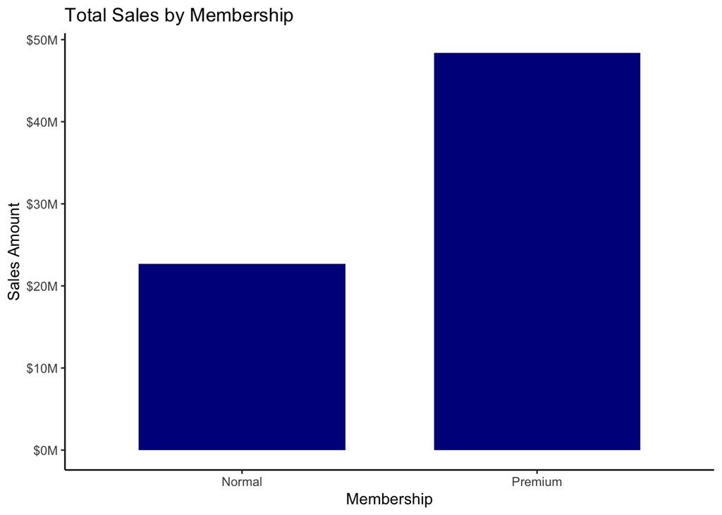

```r
 #Share - Key Visualizations From Analysis


 #Total sales by membership

 ggplot(E_commerce_data_prepared1, aes(x = membership, y = sales)) +
  geom_bar(stat = "identity", width = 0.7, fill = "darkblue") +
  labs(title = "Total Sales by Membership", x = "Membership", y = "Sales Amount") +
  theme_classic() +
   scale_y_continuous(labels = scales::dollar_format(scale = 1e-6, prefix = "$", suffix = "M"))
```

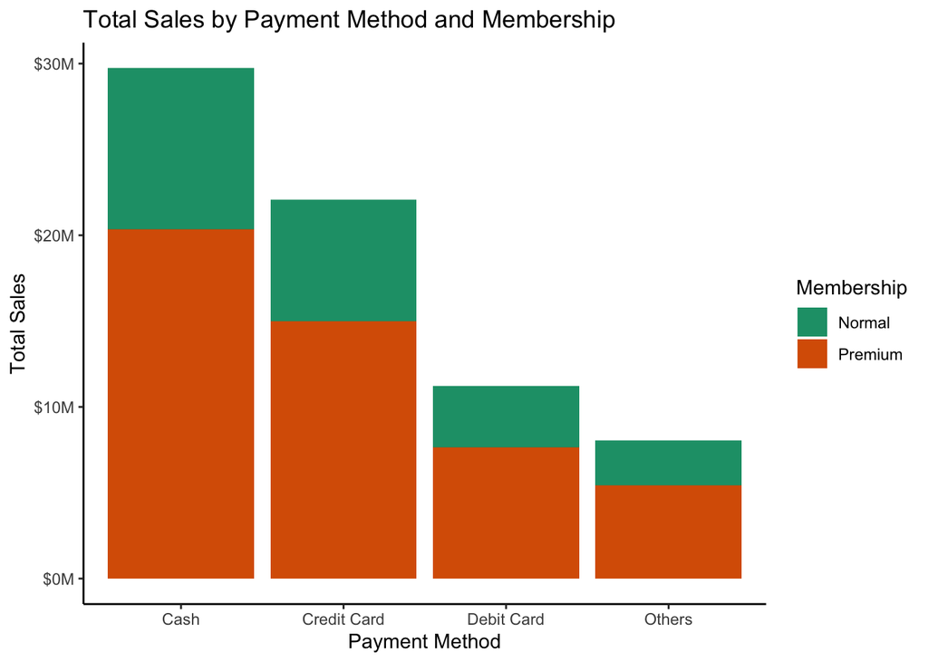

```r
 #Total sales by payment method, membership

 ggplot(E_commerce_data_prepared1, aes(x = pay_method, y = sales, fill = membership)) +
  geom_bar(stat = "identity") +
  labs(title = "Total Sales by Payment Method and Membership", x = "Payment Method", y = "Total Sales", fill = "Membership") +
  scale_fill_brewer(palette = "Dark2") +
   theme_classic() +
  scale_y_continuous(labels = scales::dollar_format(scale = 1e-6, prefix = "$", suffix = "M"))
```

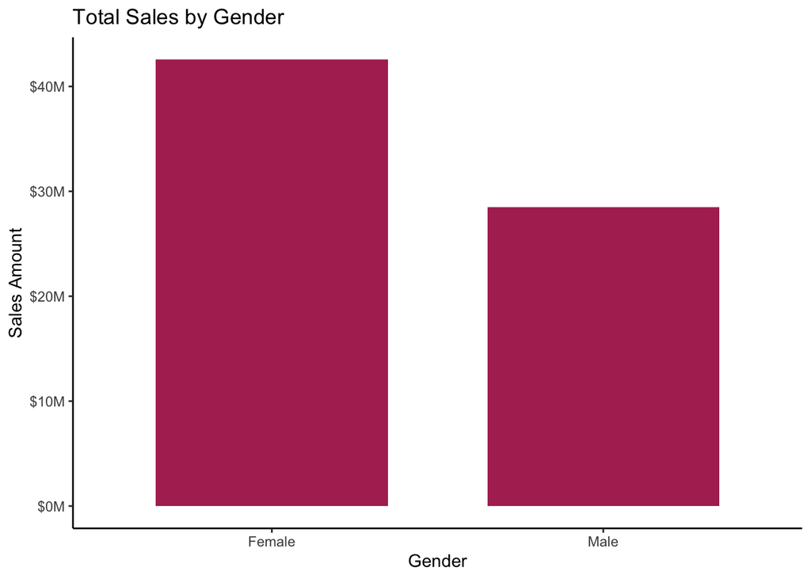

```r
 #Total sales by gender

 ggplot(E_commerce_data_prepared1, aes(x = gender, y = sales)) +
  geom_bar(stat = "identity", width = 0.7, fill = "maroon") +
  labs(title = "Total Sales by Gender", x = "Gender", y = "Sales Amount") +
  theme_classic() +
  scale_y_continuous(labels = scales::dollar_format(scale = 1e-6, prefix = "$", suffix = "M"))
```

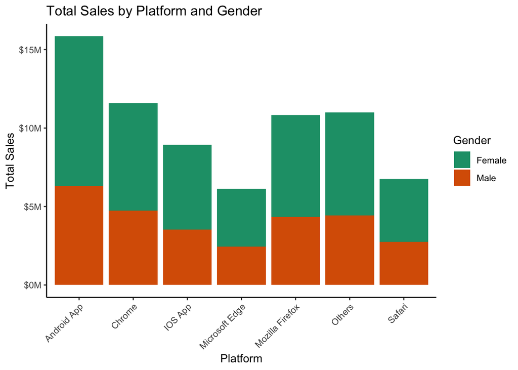

```r
 #Barplot of total sales by platform, gender

 ggplot(E_commerce_data_prepared1, aes(x = platform_used, y = sales, fill = gender)) +
  geom_bar(stat = "identity") +
  labs(title = "Total Sales by Platform and Gender", x = "Platform", y = "Total Sales", fill = "Gender") +
  scale_fill_brewer(palette = "Dark2") +
   theme_classic() +
  scale_y_continuous(labels = scales::dollar_format(scale = 1e-6, prefix = "$", suffix = "M")) +
   theme(axis.text.x = element_text(angle = 45, hjust = 1))
```

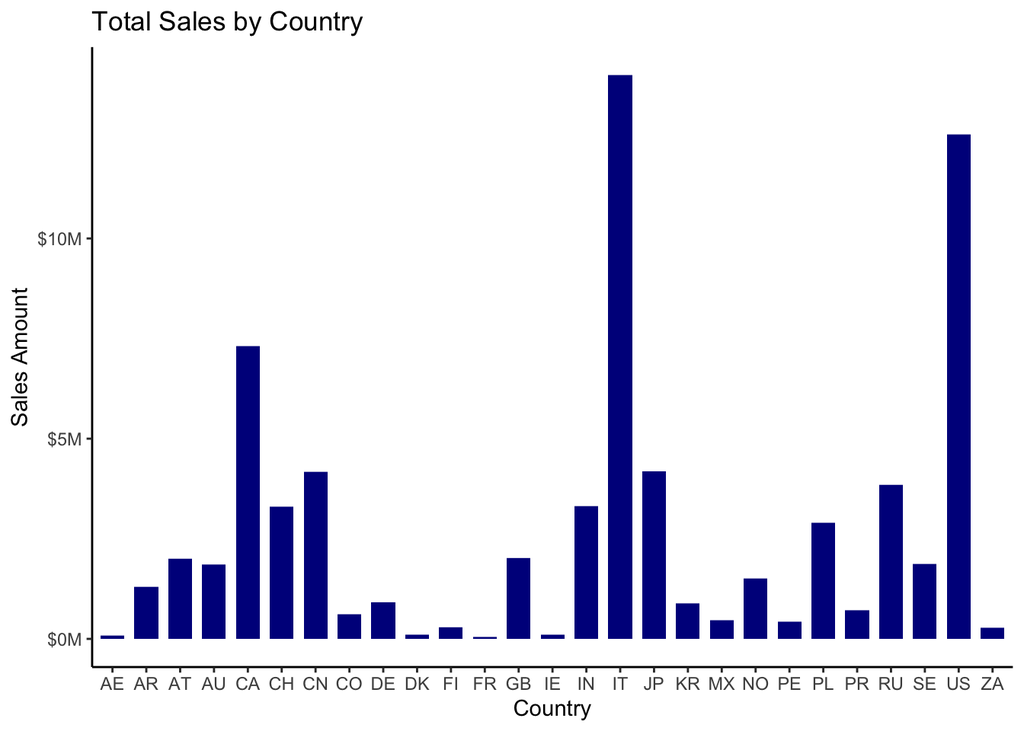

```r
 #Total sales by country

 ggplot(E_commerce_data_prepared1, aes(x = country, y = sales)) +
  geom_bar(stat = "identity", width = 0.7, fill = "darkblue") +
  labs(title = "Total Sales by Country", x = "Country", y = "Sales Amount") +
  theme_classic() +
  scale_y_continuous(labels = scales::dollar_format(scale = 1e-6, prefix = "$", suffix = "M"))
```

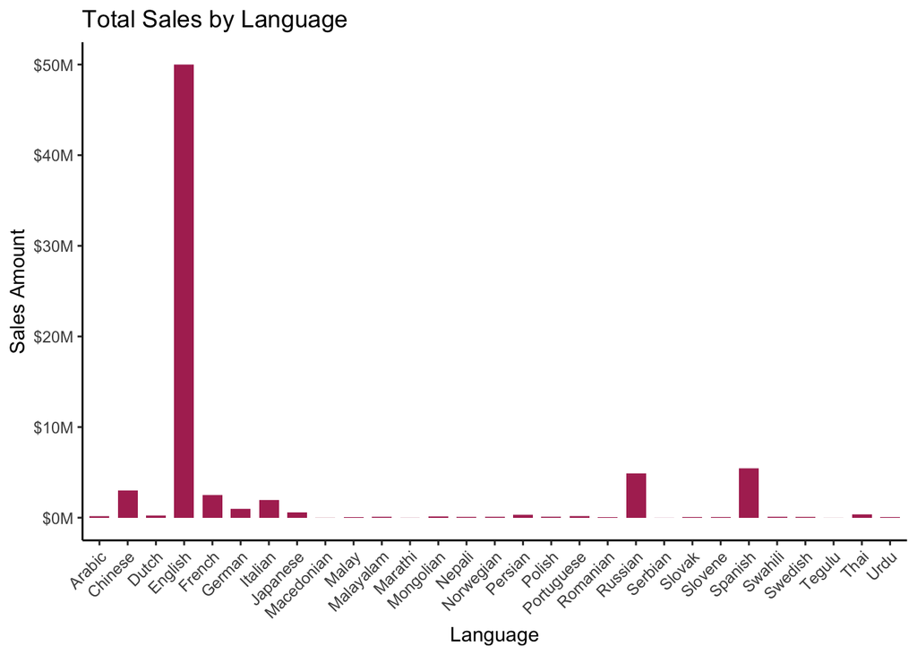

```r
 #Total sales by language

 ggplot(E_commerce_data_prepared1, aes(x = language, y = sales)) +
  geom_bar(stat = "identity", width = 0.7, fill = "maroon") +
  labs(title = "Total Sales by Language", x = "Language", y = "Sales Amount") +
  theme_classic() +
   scale_y_continuous(labels = scales::dollar_format(scale = 1e-6, prefix = "$", suffix = "M")) +
   theme(axis.text.x = element_text(angle = 45, hjust = 1))
```

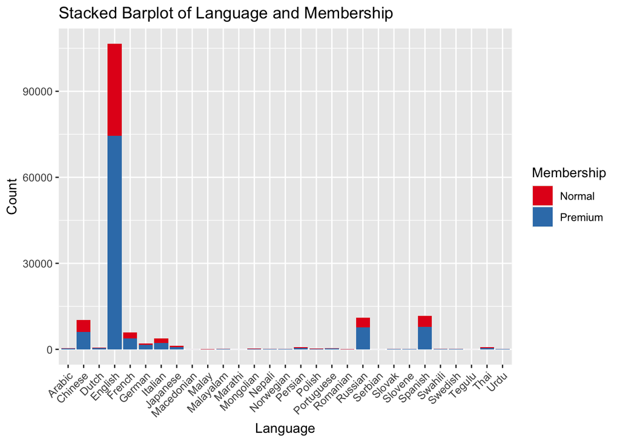

```r
 #Stacked barplot of language and membership counts

 ggplot(E_commerce_data_prepared1, aes(x = language, fill =  membership)) +
  geom_bar() +
  labs(title = "Stacked Barplot of Language and Membership",
       x = "Language",
       y = "Count", fill = "Membership") +
   theme(axis.text.x = element_text(angle = 45, hjust = 1)) +
  scale_fill_brewer(palette = "Set1")
```

In our visualizations, key insights emerge: premium members dominate sales, with proportional spending patterns across payment methods. Demographically, females contribute around 60% of total sales, and specific platforms and countries (like Android, Chrome, Italy, the United States, and Canada) stand out. Notably, English is the preferred language, constituting over 70% of sales. The stacked barplot reinforces the preference of premium membership accessed through English, as confirmed by our Chi-square test.

Consolidating these findings, we transition to the “Act” Phase, translating insights into actionable outcomes.

## Act: Leveraging Insights into Strategic Action

In the “Act” phase, we leverage our insights to propose strategic recommendations for our e-commerce website. Based on key findings, we suggest five hypothetical strategies to drive more informed, data-driven decisions:

1. Target marketing efforts and membership benefits specifically towards premium members, recognizing their significant contribution to sales.
2. Craft marketing campaigns tailored to resonate with the preferences of the female audience, acknowledging their substantial impact on revenue.
3. Implement regional targeting by tailoring advertising content to more profitable regions, such as Italy, the United States, and Canada.
4. Enhance the payment process for cash, credit, and debit cards, and optimize the user experience on preferred platforms: Android, Chrome, and Mozilla Firefox.
5. Direct website content and promotions in English to cater to the preferred language of premium users accessing the website.

By implementing these recommendations, the e-commerce platform can advance towards improved decision-making and targeted marketing strategies. However, the iterative nature of the data analytics process necessitates ongoing refinement, as we must always remain mindful to the limitations within the data, and continually purify our insights. I appreciate your participation in this exploratory data analysis journey—until next time!